# Ford GoBike System Dataset Exploration and Visualization

**Created by Alex Yu**

## Preliminary Wrangling

The bicycle-sharing service is becoming more and more popular across the globe. It allows people in metropolitan areas to rent bicycles by unlocking in one station and return in any other authorized network station. This is very convenient for short trips, especially ideal for one-way trips.

Ford GoBike, which was initiated in 2013, is one of them that was introduced to the US West Coast. Up until now, it has facilitated hundreds of thousands of people and collected millions of usage data since 2017.

```python
# import all packages and set plots to be embedded inline
import os
import numpy as np
import pandas as pd
import matplotlib.pyplot as plt
import seaborn as sns
import requests
import glob
import zipfile

%matplotlib inline
```

```python
os.chdir('projects_on_GitHub/udacity_project/FordGoBike_Visualizations')
```

```python
os.mkdir('data')
```

## Data Gathering

**In the following step, firstly we make a list of filenames in order to download data from `s2.amazonaws.com`; secondly we use `requests` library to parse the url and download data accordingly; thirdly as the downloaded files are in `zip` format, we need to unzip these files to their `csv` format. After being unzipped, the `zip` files are deleted.**

*Notice:* The data sets are stored [here](https://s3.amazonaws.com/fordgobike-data/index.html).

```python
# Create urls list for requesting data from aws s3
url_prefix = "https://s3.amazonaws.com/fordgobike-data/"
url_fliter = list(range(201801, 201813)) + list(range(201901, 201905))

urls = []
for i in url_fliter:
    url = url_prefix + str(i) + "-fordgobike-tripdata.csv.zip"
    urls.append(url)

urls.append('https://s3.amazonaws.com/fordgobike-data/2017-fordgobike-tripdata.csv')
# urls
```

```python
# Request and download data from aws s3
for url in urls:
    response = requests.get(url)
    with open(os.path.join(os.getcwd(), 'data', url.split('/')[-1]), 'wb') as infile:
        infile.write(response.content)
```

```python
# Unzip all the downloaded `.zip` files into its `.csv` format and delete the original `.zip`
for file in glob.glob(os.path.join(os.getcwd(), 'data/*.zip')):
    with zipfile.ZipFile(file, mode='r') as myFile:
        myFile.extractall(path=os.path.join(os.getcwd(), 'data'))
        os.remove(file)
```

```python
# Sort files in month order
filenames = []
for file in glob.glob('data/*.csv'):
    filenames.append(file)

filenames = sorted(filenames)
print("Total files: {}.".format(len(filenames)))
```

```
Total files: 17.
```

## Data Assessing

**1. Feature Names Consistency Check**

As these files are complied by month from 2017 to 2019, I am wondering whether the feature (column) names in each file keep consistent as time went by. So let's check it below.

```python
# Print out the number of features in each data file based on file name
column_list = []

for filename in filenames:
    df = pd.read_csv(filename, nrows=0, low_memory=False)

    print("{} features in {}".format(len(df.columns), filename))
    column_list.append(df.columns.values)

# Convert the feature names in each file to a DataFrame, indexed by the year-month of that data file
col_df = pd.DataFrame(column_list, index=[i.split('/')[1][:6] for i in filenames])
col_df
```

```
15 features in data/2017-fordgobike-tripdata.csv
16 features in data/201801-fordgobike-tripdata.csv
16 features in data/201802-fordgobike-tripdata.csv
16 features in data/201803-fordgobike-tripdata.csv
16 features in data/201804-fordgobike-tripdata.csv
16 features in data/201805-fordgobike-tripdata.csv
16 features in data/201806-fordgobike-tripdata.csv
16 features in data/201807-fordgobike-tripdata.csv
16 features in data/201808-fordgobike-tripdata.csv
16 features in data/201809-fordgobike-tripdata.csv
16 features in data/201810-fordgobike-tripdata.csv
16 features in data/201811-fordgobike-tripdata.csv
16 features in data/201812-fordgobike-tripdata.csv
16 features in data/201901-fordgobike-tripdata.csv
16 features in data/201902-fordgobike-tripdata.csv
16 features in data/201903-fordgobike-tripdata.csv
16 features in data/201904-fordgobike-tripdata.csv
```

|  | 0 | 1 | 2 | 3 | 4 | 5 | 6 | 7 | 8 | 9 | 10 | 11 | 12 | 13 | 14 | 15 |
| --- | --- | --- | --- | --- | --- | --- | --- | --- | --- | --- | --- | --- | --- | --- | --- | --- |
| 2017-f | duration_sec | start_time | end_time | start_station_id | start_station_name | start_station_latitude | start_station_longitude | end_station_id | end_station_name | end_station_latitude | end_station_longitude | bike_id | user_type | member_birth_year | member_gender | None |
| 201801 | duration_sec | start_time | end_time | start_station_id | start_station_name | start_station_latitude | start_station_longitude | end_station_id | end_station_name | end_station_latitude | end_station_longitude | bike_id | user_type | member_birth_year | member_gender | bike_share_for_all_trip |
| 201802 | duration_sec | start_time | end_time | start_station_id | start_station_name | start_station_latitude | start_station_longitude | end_station_id | end_station_name | end_station_latitude | end_station_longitude | bike_id | user_type | member_birth_year | member_gender | bike_share_for_all_trip |
| 201803 | duration_sec | start_time | end_time | start_station_id | start_station_name | start_station_latitude | start_station_longitude | end_station_id | end_station_name | end_station_latitude | end_station_longitude | bike_id | user_type | member_birth_year | member_gender | bike_share_for_all_trip |
| 201804 | duration_sec | start_time | end_time | start_station_id | start_station_name | start_station_latitude | start_station_longitude | end_station_id | end_station_name | end_station_latitude | end_station_longitude | bike_id | user_type | member_birth_year | member_gender | bike_share_for_all_trip |
| 201805 | duration_sec | start_time | end_time | start_station_id | start_station_name | start_station_latitude | start_station_longitude | end_station_id | end_station_name | end_station_latitude | end_station_longitude | bike_id | user_type | member_birth_year | member_gender | bike_share_for_all_trip |
| 201806 | duration_sec | start_time | end_time | start_station_id | start_station_name | start_station_latitude | start_station_longitude | end_station_id | end_station_name | end_station_latitude | end_station_longitude | bike_id | user_type | member_birth_year | member_gender | bike_share_for_all_trip |
| 201807 | duration_sec | start_time | end_time | start_station_id | start_station_name | start_station_latitude | start_station_longitude | end_station_id | end_station_name | end_station_latitude | end_station_longitude | bike_id | user_type | member_birth_year | member_gender | bike_share_for_all_trip |
| 201808 | duration_sec | start_time | end_time | start_station_id | start_station_name | start_station_latitude | start_station_longitude | end_station_id | end_station_name | end_station_latitude | end_station_longitude | bike_id | user_type | member_birth_year | member_gender | bike_share_for_all_trip |
| 201809 | duration_sec | start_time | end_time | start_station_id | start_station_name | start_station_latitude | start_station_longitude | end_station_id | end_station_name | end_station_latitude | end_station_longitude | bike_id | user_type | member_birth_year | member_gender | bike_share_for_all_trip |
| 201810 | duration_sec | start_time | end_time | start_station_id | start_station_name | start_station_latitude | start_station_longitude | end_station_id | end_station_name | end_station_latitude | end_station_longitude | bike_id | user_type | member_birth_year | member_gender | bike_share_for_all_trip |
| 201811 | duration_sec | start_time | end_time | start_station_id | start_station_name | start_station_latitude | start_station_longitude | end_station_id | end_station_name | end_station_latitude | end_station_longitude | bike_id | user_type | member_birth_year | member_gender | bike_share_for_all_trip |
| 201812 | duration_sec | start_time | end_time | start_station_id | start_station_name | start_station_latitude | start_station_longitude | end_station_id | end_station_name | end_station_latitude | end_station_longitude | bike_id | user_type | member_birth_year | member_gender | bike_share_for_all_trip |
| 201901 | duration_sec | start_time | end_time | start_station_id | start_station_name | start_station_latitude | start_station_longitude | end_station_id | end_station_name | end_station_latitude | end_station_longitude | bike_id | user_type | member_birth_year | member_gender | bike_share_for_all_trip |
| 201902 | duration_sec | start_time | end_time | start_station_id | start_station_name | start_station_latitude | start_station_longitude | end_station_id | end_station_name | end_station_latitude | end_station_longitude | bike_id | user_type | member_birth_year | member_gender | bike_share_for_all_trip |
| 201903 | duration_sec | start_time | end_time | start_station_id | start_station_name | start_station_latitude | start_station_longitude | end_station_id | end_station_name | end_station_latitude | end_station_longitude | bike_id | user_type | member_birth_year | member_gender | bike_share_for_all_trip |
| 201904 | duration_sec | start_time | end_time | start_station_id | start_station_name | start_station_latitude | start_station_longitude | end_station_id | end_station_name | end_station_latitude | end_station_longitude | bike_id | user_type | member_birth_year | member_gender | bike_share_for_all_trip |

```python
def print_col_names(df):
    """Print out the column names in the dataset"""
    for idx, col_name in enumerate(df.columns.values, start=1):
        print(idx, col_name)
```

```python
df_2017 = pd.read_csv('data/2017-fordgobike-tripdata.csv')
df_201801 = pd.read_csv('data/201801-fordgobike-tripdata.csv')

print("***Feature names in 2017:***")
print_col_names(df_2017)
print()
print("***Feature names after 2017:***")
print_col_names(df_201801)
```

```
***Feature names in 2017:***
1 duration_sec
2 start_time
3 end_time
4 start_station_id
5 start_station_name
6 start_station_latitude
7 start_station_longitude
8 end_station_id
9 end_station_name
10 end_station_latitude
11 end_station_longitude
12 bike_id
13 user_type
14 member_birth_year
```

[output cut: 19 more lines]

*Summary - Data Structure and Feature Consistency Check:*

As we can see from above, the feature (column) names after 2017 are exactly the same: **16 features** in total. But for 2017, there are only **15 features** in the dataset, or there is no `bike_share_for_all` column while the rest of feature names staying the same as those in 2018 and 2019.

```python
def concat_csvs(filenames):
    """Concatenate multiple csv format data based on file names."""

    # Store the read-in DataFrame in a list
    dfs = []

    # Iterate filenames list and read data into pandas DataFrame
    for filename in filenames:
        df = pd.read_csv(filename, low_memory=False)
        dfs.append(df)

    return pd.concat(dfs, ignore_index=True)
```

```python
master_df = concat_csvs(filenames)
```

```python
master_df.sample(20)
```

|  | duration_sec | start_time | end_time | start_station_id | start_station_name | start_station_latitude | start_station_longitude | end_station_id | end_station_name | end_station_latitude | end_station_longitude | bike_id | user_type | member_birth_year | member_gender | bike_share_for_all_trip |
| --- | --- | --- | --- | --- | --- | --- | --- | --- | --- | --- | --- | --- | --- | --- | --- | --- |
| 726989 | 1121 | 2018-03-30 10:42:43.6380 | 2018-03-30 11:01:25.3200 | 8.0 | The Embarcadero at Vallejo St | 37.799953 | -122.398525 | 8.0 | The Embarcadero at Vallejo St | 37.799953 | -122.398525 | 24 | Customer | NaN | NaN | No |
| 715360 | 1416 | 2018-02-02 08:52:34.3010 | 2018-02-02 09:16:10.6610 | 146.0 | 30th St at San Jose Ave | 37.742314 | -122.423180 | 93.0 | 4th St at Mission Bay Blvd S | 37.770407 | -122.391198 | 2457 | Subscriber | 1983.0 | Male | No |
| 7151 | 489 | 2017-12-27 16:49:36.7680 | 2017-12-27 16:57:46.6010 | 241.0 | Ashby BART Station | 37.852477 | -122.270213 | 173.0 | Shattuck Ave at 55th Ave | 37.840364 | -122.264488 | 125 | Customer | 1990.0 | Female | NaN |
| 345344 | 701 | 2017-09-15 08:42:02.4140 | 2017-09-15 08:53:44.2710 | 144.0 | Precita Park | 37.747300 | -122.411403 | 58.0 | Market St at 10th St | 37.776619 | -122.417385 | 2835 | Subscriber | 1989.0 | Male | NaN |
| 2575722 | 1400 | 2019-02-28 22:05:50.7840 | 2019-02-28 22:29:11.1900 | 8.0 | The Embarcadero at Vallejo St | 37.799953 | -122.398525 | 109.0 | 17th St at Valencia St | 37.763316 | -122.421904 | 4822 | Subscriber | 1994.0 | Male | No |
| 2069035 | 267 | 2018-10-08 12:55:18.9250 | 2018-10-08 12:59:46.3200 | 93.0 | 4th St at Mission Bay Blvd S | 37.770407 | -122.391198 | 92.0 | Mission Bay Kids Park | 37.772301 | -122.393028 | 1882 | Customer | 1980.0 | Male | No |
| 1407164 | 898 | 2018-07-21 12:47:41.7740 | 2018-07-21 13:02:40.5610 | 5.0 | Powell St BART Station (Market St at 5th St) | 37.783899 | -122.408445 | 67.0 | San Francisco Caltrain Station 2 (Townsend St... | 37.776639 | -122.395526 | 3214 | Customer | NaN | NaN | No |
| 2365863 | 842 | 2018-12-05 08:51:29.7830 | 2018-12-05 09:05:32.0870 | 375.0 | Grove St at Masonic Ave | 37.774836 | -122.446546 | 5.0 | Powell St BART Station (Market St at 5th St) | 37.783899 | -122.408445 | 757 | Subscriber | 1994.0 | Female | No |
| 2912386 | 739 | 2019-03-14 12:55:03.9890 | 2019-03-14 13:07:23.7780 | 171.0 | Rockridge BART Station | 37.844279 | -122.251900 | 239.0 | Bancroft Way at Telegraph Ave | 37.868813 | -122.258764 | 5613 | Subscriber | 1958.0 | Male | No |
| 1245076 | 94 | 2018-06-15 11:57:28.9690 | 2018-06-15 11:59:03.4820 | 280.0 | San Fernando at 7th St | 37.337246 | -121.883074 | 281.0 | 9th St at San Fernando | 37.338395 | -121.880797 | 1844 | Subscriber | 1990.0 | Male | Yes |
| 1025650 | 195 | 2018-05-21 10:12:35.2170 | 2018-05-21 10:15:51.1690 | 4.0 | Cyril Magnin St at Ellis St | 37.785881 | -122.408915 | 44.0 | Civic Center/UN Plaza BART Station (Market St ... | 37.781074 | -122.411738 | 3371 | Subscriber | 1981.0 | Male | No |
| 1577551 | 592 | 2018-08-25 14:11:18.7300 | 2018-08-25 14:21:10.9190 | 195.0 | Bay Pl at Vernon St | 37.812314 | -122.260779 | 182.0 | 19th Street BART Station | 37.809013 | -122.268247 | 1464 | Subscriber | 1952.0 | Male | No |
| 1858442 | 908 | 2018-09-11 10:49:30.1770 | 2018-09-11 11:04:38.5800 | 323.0 | Broadway at Kearny | 37.798014 | -122.405950 | 17.0 | Embarcadero BART Station (Beale St at Market St) | 37.792251 | -122.397086 | 3494 | Subscriber | 1990.0 | Male | No |
| 3024168 | 3409 | 2019-04-29 17:42:32.9540 | 2019-04-29 18:39:22.3380 | 252.0 | Channing Way at Shattuck Ave | 37.865847 | -122.267443 | 253.0 | Haste St at College Ave | 37.866418 | -122.253799 | 3351 | Subscriber | 2000.0 | Female | Yes |
| 114159 | 368 | 2017-11-21 09:00:31.6510 | 2017-11-21 09:06:40.3750 | 59.0 | S Van Ness Ave at Market St | 37.774814 | -122.418954 | 88.0 | 11th St at Bryant St | 37.770030 | -122.411726 | 3159 | Subscriber | 1987.0 | Male | NaN |
| 1204907 | 764 | 2018-06-21 18:19:02.2380 | 2018-06-21 18:31:47.2210 | 349.0 | Howard St at Mary St | 37.781010 | -122.405666 | 67.0 | San Francisco Caltrain Station 2 (Townsend St... | 37.776639 | -122.395526 | 2076 | Subscriber | 1993.0 | Male | No |
| 2896344 | 243 | 2019-03-15 21:23:29.8590 | 2019-03-15 21:27:33.5610 | 256.0 | Hearst Ave at Euclid Ave | 37.875112 | -122.260553 | 244.0 | Shattuck Ave at Hearst Ave | 37.873676 | -122.268487 | 5493 | Customer | 1999.0 | Male | No |
| 2468250 | 7466 | 2019-01-21 17:15:10.3710 | 2019-01-21 19:19:36.5050 | 8.0 | The Embarcadero at Vallejo St | 37.799953 | -122.398525 | 8.0 | The Embarcadero at Vallejo St | 37.799953 | -122.398525 | 3710 | Customer | NaN | NaN | No |
| 128519 | 541 | 2017-11-16 08:31:51.1710 | 2017-11-16 08:40:53.0950 | 66.0 | 3rd St at Townsend St | 37.778742 | -122.392741 | 5.0 | Powell St BART Station (Market St at 5th St) | 37.783899 | -122.408445 | 1152 | Subscriber | 1985.0 | Male | NaN |
| 1785481 | 388 | 2018-09-21 19:15:40.1810 | 2018-09-21 19:22:08.8220 | 291.0 | Autumn Parkway at Coleman Ave | 37.341335 | -121.903183 | 305.0 | Ryland Park | 37.342725 | -121.895617 | 3708 | Subscriber | 1994.0 | Female | Yes |

**2. Merged Data Overview & Data Type Check**

*Total Records and Number of Features Check:*

```python
# Number of records and number of features in the DataFrame
master_df.shape
```

```
(3254325, 16)
```

We can tell from above that after merging all the data together, there are up to **3,254,325** records and **16** columns in the dataset.

```python
master_df.describe()
```

|  | duration_sec | start_station_id | start_station_latitude | start_station_longitude | end_station_id | end_station_latitude | end_station_longitude | bike_id | member_birth_year |
| --- | --- | --- | --- | --- | --- | --- | --- | --- | --- |
| count | 3.254325e+06 | 3.241824e+06 | 3.254325e+06 | 3.254325e+06 | 3.241824e+06 | 3.254325e+06 | 3.254325e+06 | 3.254325e+06 | 3.036159e+06 |
| mean | 8.743223e+02 | 1.209191e+02 | 3.776880e+01 | -1.223530e+02 | 1.191966e+02 | 3.776874e+01 | -1.223519e+02 | 2.729018e+03 | 1.983137e+03 |
| std | 2.468547e+03 | 1.030184e+02 | 1.029275e-01 | 1.601559e-01 | 1.029334e+02 | 1.342571e-01 | 3.220803e-01 | 1.724443e+03 | 1.043760e+01 |
| min | 6.100000e+01 | 3.000000e+00 | 0.000000e+00 | -1.224737e+02 | 3.000000e+00 | 0.000000e+00 | -1.224737e+02 | 1.000000e+01 | 1.878000e+03 |
| 25% | 3.510000e+02 | 3.100000e+01 | 3.777106e+01 | -1.224117e+02 | 3.000000e+01 | 3.777143e+01 | -1.224108e+02 | 1.336000e+03 | 1.978000e+03 |
| 50% | 5.570000e+02 | 8.800000e+01 | 3.778107e+01 | -1.223983e+02 | 8.700000e+01 | 3.778127e+01 | -1.223974e+02 | 2.579000e+03 | 1.985000e+03 |
| 75% | 8.730000e+02 | 1.880000e+02 | 3.779539e+01 | -1.222934e+02 | 1.860000e+02 | 3.779625e+01 | -1.222935e+02 | 3.821000e+03 | 1.991000e+03 |
| max | 8.636900e+04 | 4.200000e+02 | 4.551000e+01 | 0.000000e+00 | 4.200000e+02 | 4.551000e+01 | 0.000000e+00 | 7.108000e+03 | 2.001000e+03 |

It seems there is an incredible value in `member_birth_year` which equals to **1878**. If a man/woman was born in **1878**, he/she would be **141 years old** base on the year of 2019! This is rarely possible.

*Data Type Check:*

```python
master_df.info(verbose=True, null_counts=True)
```

```
<class 'pandas.core.frame.DataFrame'>
RangeIndex: 3254325 entries, 0 to 3254324
Data columns (total 16 columns):
 #   Column                   Non-Null Count    Dtype
---  ------                   --------------    -----
 0   duration_sec             3254325 non-null  int64
 1   start_time               3254325 non-null  object
 2   end_time                 3254325 non-null  object
 3   start_station_id         3241824 non-null  float64
 4   start_station_name       3241824 non-null  object
 5   start_station_latitude   3254325 non-null  float64
 6   start_station_longitude  3254325 non-null  float64
 7   end_station_id           3241824 non-null  float64
 8   end_station_name         3241824 non-null  object
 9   end_station_latitude     3254325 non-null  float64
 10  end_station_longitude    3254325 non-null  float64
 11  bike_id                  3254325 non-null  int64
 12  user_type                3254325 non-null  object
 13  member_birth_year        3036159 non-null  float64
 14  member_gender            3036592 non-null  object
 15  bike_share_for_all_trip  2734625 non-null  object
dtypes: float64(7), int64(2), object(7)
memory usage: 397.3+ MB
```

*Summary - Data Type Check:*

As shown from above, I find several inappropriate data types in the dataset as follows,

- `start_time`, `end_time` could be `timestamps` data type instead of `object` (string).
- `start_station_id`, `end_station_id`, `bike_id` could be `object` (string) instead of `float64`.
- `member_birth_year` could be `int` instead of `float64`.
- `member_gender`, `bike_share_for_all_trip` could be `CategoricalDtype` instead of `object` (string).

**3. Missing Values Evaluation**

#### Overview

Previously, we have used `.info()` method to take a brief look at the data type of the dataset, we can get to know about the missingness of the data as well (*as follows*).

```python
master_df.info(verbose=True, null_counts=True)
```

```
<class 'pandas.core.frame.DataFrame'>
RangeIndex: 3254325 entries, 0 to 3254324
Data columns (total 16 columns):
 #   Column                   Non-Null Count    Dtype
---  ------                   --------------    -----
 0   duration_sec             3254325 non-null  int64
 1   start_time               3254325 non-null  object
 2   end_time                 3254325 non-null  object
 3   start_station_id         3241824 non-null  float64
 4   start_station_name       3241824 non-null  object
 5   start_station_latitude   3254325 non-null  float64
 6   start_station_longitude  3254325 non-null  float64
 7   end_station_id           3241824 non-null  float64
 8   end_station_name         3241824 non-null  object
 9   end_station_latitude     3254325 non-null  float64
 10  end_station_longitude    3254325 non-null  float64
 11  bike_id                  3254325 non-null  int64
 12  user_type                3254325 non-null  object
 13  member_birth_year        3036159 non-null  float64
 14  member_gender            3036592 non-null  object
 15  bike_share_for_all_trip  2734625 non-null  object
dtypes: float64(7), int64(2), object(7)
memory usage: 397.3+ MB
```

It seems there are **7 columns** with missing values:

1. `start_station_id`,
2. `start_station_name`,
3. `end_station_id`,
4. `end_station_name`,
5. `member_birth_year`,
6. `member_gender`,
7. `bike_share_for_all_trip`

We can dive in deeper by calculating the amount and relative percentage of missingness in each column (feature).

```python
# Select columns only with missing values
df_has_nulls = master_df.loc[:, master_df.isna().any()]

# Counts of missing values in each column
col_null_count = df_has_nulls.isna().sum()
print('Absoulute count (#):', col_null_count.sort_values(ascending=False), sep='\n')
print()

# Relative frequency or percentage of missing values in each column
col_null_perc = df_has_nulls.isna().mean() * 100
print('Percentage (%):', col_null_perc.sort_values(ascending=False), sep='\n')
```

```
Absoulute count (#):
bike_share_for_all_trip    519700
member_birth_year          218166
member_gender              217733
end_station_name            12501
end_station_id              12501
start_station_name          12501
start_station_id            12501
dtype: int64

Percentage (%):
bike_share_for_all_trip    15.969517
member_birth_year           6.703879
member_gender               6.690573
end_station_name            0.384135
end_station_id              0.384135
start_station_name          0.384135
start_station_id            0.384135
dtype: float64
```

Furthermore, I will utilize missingno package to visualize the missingness and try to find if there is any relationship bewteen these columns with missing values.

```python
# Install the missingno package if not
# !pip install missinno
```

```python
import missingno as msno
```

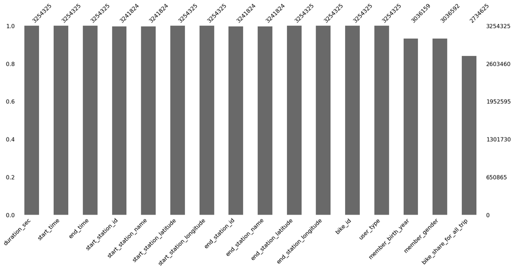

```python
msno.bar(master_df);
```

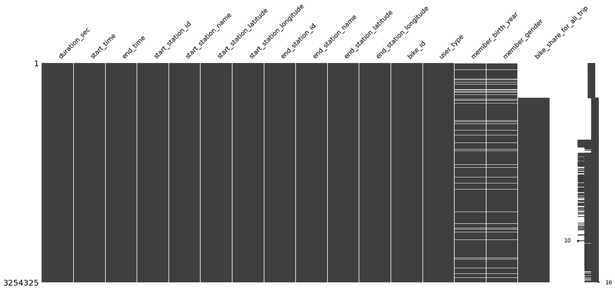

```python
msno.matrix(master_df);
```

*Summary - Missingness Check:*

The visualized missingness is similar to the statistical summary we got previously. Interestingly we can see that the missingness in `member_birth_year` and `member_gender` seems to happen at the same time which means that if the record in `member_birth_year` is absent, the record in `member_gender` of the same row is also absent. So ignoring them won't have much impact on the information the original dataset holds. (If the missingness in these two columns happens in different records (rows), we may lose more data or information.) As for the `bike_share_for_all_trip` which is a programme initiated since 2018, the missingness in the year of 2017 is intuitive.

#### 4. Duplicates Check

Next I will check whether there are duplicated records in the dataset.

```python
# Duplicates check
master_df.duplicated().sum()
```

```
0
```

*Summary - Duplicates Check:*

We can tell there are no duplicates in the dataset, so we don't need todo anything with it.

Now we can answer the following questions based on the analysis from above.

### What is the structure of your dataset?

> I retrieved the data from Ford GoBike's [AWS S3 Storage](https://s3.amazonaws.com/fordgobike-data/index.html) which includes **1** `.csv` file and **16** `.zip` file.

> After combining these files, I found that it has **3,254,325 records** covering **23 months** of usage data ranging between *June 2017 and April 2019*, although data in 2017 has **15** features without `bike_share_for_all_trip` column, the rest are exactly the same.

> **16 features** includes:
> - `duration_sec`
> - `start_time`
> - `end_time`
> - `start_station_id`
> - `start_station_name`
> - `start_station_latitude`
> - `start_station_longitude`
> - `end_station_id`
> - `end_station_name`
> - `end_station_latitude`
> - `end_station_longitude`
> - `bike_id`
> - `user_type`
> - `member_birth_year`
> - `member_gender`
> - `bike_share_for_all_trip`

### What is/are the main feature(s) of interest in your dataset?

> The ultimate goal of the project is to analyze what kinds of people are using the Ford GoBike service in the SF Bay Area and how they are using it. As we can see from the 16 features listed above, I think the main feature of interest is `duration_sec` as it is directly correlated with the profits of the service and can help answer the question '*How are they using it?*'. As per the question '*What kinds of people are using the service?*', I find helpful features such as `user_type`, `member_birth_year`, `bike_share_for_all_trip`. Namely,

> **What kinds of people are using the Ford GoBike Service?**
> > - `user_type`
> > - `member_birth_year`
> > - `member_gender`
> > - `bike_share_for_all_trip`

> **How are they using it?**
> > - `duration_sec`
> > - `trip_distance_km`

### What features in the dataset do you think will help support your investigation into your feature(s) of interest?

> Besides the raw featrues listed above in the dataset, I think it would be worthwhile to derive some other features such as `member_age`, `year`, `month`, `date`, `day_of_week`, `hour` etc. based on the original column `member_birth_year` and `start_time` or `end_time` because they would allow us to dive deeper into how these factors interact with or affect the `duration_sec` in finer granularity. Moreover, these derived ones would be more intuitive and interpretable to communicate the analytical results to the public compared with the raw features.

**For the convenience of data cleaning, I conclude once again the data quality analysis result from above as below，just at the head of Data Cleaning Part.**

### Quality Issues

1. Columns have missing values：
   - `start_station_id` - *nullity: 0.38%*,
   - `start_station_name` - *nullity: 0.38%*,
   - `end_station_id` - *nullity: 0.38%*,
   - `end_station_name` - *nullity: 0.38%*,
   - `member_birth_year` - *nullity: 6.7%*,
   - `member_gender` - *nullity: 6.7%*,
   - `bike_share_for_all_trip` - *nullity: 15.97%*.
1. `member_birth_year` could be `int` instead of `float64`.
1. `member_gender`, `bike_share_for_all_trip` could be `CategoricalDtype` instead of `object` (string).
1. `start_station_id`, `end_station_id`, `bike_id` could be `object` (string) instead of `float64` or `int`.
1. `start_time`, `end_time` could be `timestamps` data type instead of `object` (string).
1. Some new features need to be derived:
   - `member_age` from `member_birth_year`
   - `start_month` from `start_time`
   - `start_date` from `start_time`
   - `start_day_of_week` from `start_time` (See *Remark 1*.)
   - `start_hour` from `start_time`
   - `trip_distance` from `start_station_latitude`, `start_station_longitude`, `end_station_latitude`, `end_station_longitude` ((See *Remark 2*.))

> *Remark 1:* After `start_day_of_week` is created, we can order them in real world by using `pd.api.types.CategoricalDtype`. *Remark 2:* This can be achieved by using `distance()` function from `geopy.distance` package.
1. Abnormal value in `member_birth_year` with **1878**.

## Data Cleaning

```python
master_clean = master_df.copy(deep=True)
```

#### 1. Dealing with Missing Values.

*Define:*

Ignore the missingness in the dataset by using `.notnull()` function.

*Code:*

```python
# Only select the data in which the `start_station_id`, is not null
master_clean = master_clean[master_clean.start_station_id.notnull()]

# Only select the data in which the `member_birth_year` is not null
master_clean = master_clean[master_clean.member_birth_year.notnull()].reset_index(drop=True)
```

*Test:*

```python
master_clean.info(verbose=True, null_counts=True)
```

```
<class 'pandas.core.frame.DataFrame'>
RangeIndex: 3023992 entries, 0 to 3023991
Data columns (total 16 columns):
 #   Column                   Non-Null Count    Dtype
---  ------                   --------------    -----
 0   duration_sec             3023992 non-null  int64
 1   start_time               3023992 non-null  object
 2   end_time                 3023992 non-null  object
 3   start_station_id         3023992 non-null  float64
 4   start_station_name       3023992 non-null  object
 5   start_station_latitude   3023992 non-null  float64
 6   start_station_longitude  3023992 non-null  float64
 7   end_station_id           3023992 non-null  float64
 8   end_station_name         3023992 non-null  object
 9   end_station_latitude     3023992 non-null  float64
 10  end_station_longitude    3023992 non-null  float64
 11  bike_id                  3023992 non-null  int64
 12  user_type                3023992 non-null  object
 13  member_birth_year        3023992 non-null  float64
 14  member_gender            3023992 non-null  object
 15  bike_share_for_all_trip  2570833 non-null  object
dtypes: float64(7), int64(2), object(7)
memory usage: 369.1+ MB
```

#### 2. Data Type Conversion.

As the syntax of `datetime` object conversion is slightly different from the normal ones like `int`, `category` etc., I will put it to the very next part.

*Define:*

1. Convert data type in `member_birth_year` to be `int` from `float64`.
2. Convert data type in `member_gender`, `bike_share_for_all_trip`, `user_type` to be `CategoricalDtype` from `object`.
3. Convert `start_station_id`, `end_station_id`, `bike_id` to be `object` (string) from `float64` or `int`.

*Code:*

```python
# def dt_convert(col_name, type_):
#     master_clean.col_name = master_clean.col_name.astype(type_)

to_be_converted = [('member_birth_year', int), \
                   ('member_gender', 'category'), \
                   ('bike_share_for_all_trip', 'category'), \
                   ('user_type', 'category'), \
                   ('start_station_id', str), \
                   ('end_station_id', str), \
                   ('bike_id', str)]

for col_name, type_ in to_be_converted:
    try:
        master_clean.loc[:, col_name] = master_clean.loc[:, col_name].astype(type_)
    except Exception as e:
        print("Failed:", col_name, e)

# master_clean.member_birth_year = master_clean.member_birth_year.astype(int)

# master_clean.member_birth_year = master_clean.member_gender.astype('category')
# master_clean.bike_share_for_all_trip = master_clean.bike_share_for_all_trip.astype('category')
```

*Test:*

```python
master_clean.info(verbose=True, null_counts=True)
```

```
<class 'pandas.core.frame.DataFrame'>
RangeIndex: 3023992 entries, 0 to 3023991
Data columns (total 16 columns):
 #   Column                   Non-Null Count    Dtype
---  ------                   --------------    -----
 0   duration_sec             3023992 non-null  int64
 1   start_time               3023992 non-null  object
 2   end_time                 3023992 non-null  object
 3   start_station_id         3023992 non-null  object
 4   start_station_name       3023992 non-null  object
 5   start_station_latitude   3023992 non-null  float64
 6   start_station_longitude  3023992 non-null  float64
 7   end_station_id           3023992 non-null  object
 8   end_station_name         3023992 non-null  object
 9   end_station_latitude     3023992 non-null  float64
 10  end_station_longitude    3023992 non-null  float64
 11  bike_id                  3023992 non-null  object
 12  user_type                3023992 non-null  category
 13  member_birth_year        3023992 non-null  int64
 14  member_gender            3023992 non-null  category
 15  bike_share_for_all_trip  2570833 non-null  category
dtypes: category(3), float64(4), int64(2), object(7)
memory usage: 308.6+ MB
```

#### 3. `datetime` data type conversion.

*Define:*

Convert `start_time`, `end_time` to be `timestamps` data type from `object` (string).

*Code:*

```python
master_clean.start_time = pd.to_datetime(master_clean.start_time, format='%Y-%m-%d %H:%M:%S')
master_clean.end_time = pd.to_datetime(master_clean.end_time, format='%Y-%m-%d %H:%M:%S')
```

*Test:*

```python
master_clean.info(verbose=True, null_counts=True)
```

```
<class 'pandas.core.frame.DataFrame'>
RangeIndex: 3023992 entries, 0 to 3023991
Data columns (total 16 columns):
 #   Column                   Non-Null Count    Dtype
---  ------                   --------------    -----
 0   duration_sec             3023992 non-null  int64
 1   start_time               3023992 non-null  datetime64[ns]
 2   end_time                 3023992 non-null  datetime64[ns]
 3   start_station_id         3023992 non-null  object
 4   start_station_name       3023992 non-null  object
 5   start_station_latitude   3023992 non-null  float64
 6   start_station_longitude  3023992 non-null  float64
 7   end_station_id           3023992 non-null  object
 8   end_station_name         3023992 non-null  object
 9   end_station_latitude     3023992 non-null  float64
 10  end_station_longitude    3023992 non-null  float64
 11  bike_id                  3023992 non-null  object
 12  user_type                3023992 non-null  category
 13  member_birth_year        3023992 non-null  int64
 14  member_gender            3023992 non-null  category
 15  bike_share_for_all_trip  2570833 non-null  category
dtypes: category(3), datetime64[ns](2), float64(4), int64(2), object(5)
memory usage: 308.6+ MB
```

```python
master_clean.sample(10)
```

|  | duration_sec | start_time | end_time | start_station_id | start_station_name | start_station_latitude | start_station_longitude | end_station_id | end_station_name | end_station_latitude | end_station_longitude | bike_id | user_type | member_birth_year | member_gender | bike_share_for_all_trip |
| --- | --- | --- | --- | --- | --- | --- | --- | --- | --- | --- | --- | --- | --- | --- | --- | --- |
| 2207035 | 697 | 2019-01-30 16:31:51.841 | 2019-01-30 16:43:29.305 | 321.0 | 5th St at Folsom | 37.780146 | -122.403071 | 28.0 | The Embarcadero at Bryant St | 37.787168 | -122.388098 | 5247 | Customer | 1980 | Male | No |
| 2544608 | 644 | 2019-02-02 13:20:31.832 | 2019-02-02 13:31:15.930 | 119.0 | 18th St at Noe St | 37.761047 | -122.432642 | 86.0 | Market St at Dolores St | 37.769305 | -122.426826 | 2459 | Subscriber | 1991 | Male | No |
| 2863444 | 1294 | 2019-04-19 15:23:15.220 | 2019-04-19 15:44:49.625 | 377.0 | Fell St at Stanyan St | 37.771917 | -122.453704 | 58.0 | Market St at 10th St | 37.776619 | -122.417385 | 524 | Customer | 1988 | Other | No |
| 2881522 | 507 | 2019-04-17 06:58:16.414 | 2019-04-17 07:06:44.309 | 324.0 | Union Square (Powell St at Post St) | 37.788300 | -122.408531 | 67.0 | San Francisco Caltrain Station 2 (Townsend St... | 37.776639 | -122.395526 | 1375 | Subscriber | 1990 | Male | No |
| 155326 | 164 | 2017-11-03 09:34:58.483 | 2017-11-03 09:37:42.960 | 138.0 | Jersey St at Church St | 37.750900 | -122.427411 | 134.0 | Valencia St at 24th St | 37.752428 | -122.420628 | 2276 | Subscriber | 1970 | Male | NaN |
| 2581555 | 327 | 2019-03-28 08:59:29.744 | 2019-03-28 09:04:57.352 | 67.0 | San Francisco Caltrain Station 2 (Townsend St... | 37.776639 | -122.395526 | 5.0 | Powell St BART Station (Market St at 5th St) | 37.783899 | -122.408445 | 4417 | Subscriber | 1995 | Male | No |
| 2636712 | 570 | 2019-03-21 08:33:00.304 | 2019-03-21 08:42:30.583 | 42.0 | San Francisco City Hall (Polk St at Grove St) | 37.778650 | -122.418230 | 114.0 | Rhode Island St at 17th St | 37.764478 | -122.402570 | 5221 | Subscriber | 1966 | Male | No |
| 1607055 | 864 | 2018-09-25 14:41:57.803 | 2018-09-25 14:56:22.665 | 36.0 | Folsom St at 3rd St | 37.783830 | -122.398870 | 17.0 | Embarcadero BART Station (Beale St at Market St) | 37.792251 | -122.397086 | 3110 | Subscriber | 1952 | Male | No |
| 468146 | 355 | 2018-01-27 17:58:28.954 | 2018-01-27 18:04:24.450 | 45.0 | 5th St at Howard St | 37.781752 | -122.405127 | 78.0 | Folsom St at 9th St | 37.773717 | -122.411647 | 1107 | Subscriber | 1995 | Female | No |
| 1543215 | 260 | 2018-08-06 17:17:36.408 | 2018-08-06 17:21:57.144 | 8.0 | The Embarcadero at Vallejo St | 37.799953 | -122.398525 | 15.0 | San Francisco Ferry Building (Harry Bridges Pl... | 37.795392 | -122.394203 | 1556 | Subscriber | 1967 | Male | No |

```python
# master_clean.resample('A', on='start_time').duration_sec.count()
```

#### 4. Feature Extraction

**I. Time-Based Feature Extraction**

*Task 1.*

*Define:*

For the analysis and presentation purposes illustrated above, I will derive some new features from the original dataset. The following new features can be drived:

- Create `member_age` from `member_birth_year`
- Create `start_time_year` from `start_time`
- Create `start_time_year_month` from `start_time`
- Create `start_time_year_month_date` from `start_time`
- Create `start_time_month` from `start_time`
- Create `start_time_date` from `start_time`
- Create `start_time_dow` from `start_time`
- Create `start_time_hour` from `start_time`

**_Notice: Set base year for calculating `member_age` to be the year of 2019._**

*Code:*

```python
# Extract month, date, day of week (name) and hour from `start_time` respectively
master_clean.loc[:, 'start_time_year'] = master_clean.start_time.dt.year
master_clean.loc[:, 'start_time_year_month'] = master_clean.start_time.dt.to_period('M')
master_clean.loc[:, 'start_time_year_month_date'] = master_clean.start_time.dt.to_period('D')
master_clean.loc[:, 'start_time_month'] = master_clean.start_time.dt.month
master_clean.loc[:, 'start_time_date'] = master_clean.start_time.dt.day
master_clean.loc[:, 'start_time_dow'] = master_clean.start_time.dt.strftime('%a')
master_clean.loc[:, 'start_time_hour'] = master_clean.start_time.dt.hour
```

```python
# Calculate `member_age` from `member_birth_year` based on the base year
year_base = 2019

master_clean.loc[:, 'member_age'] = year_base- master_clean.member_birth_year
```

*Test:*

```python
master_clean.info(verbose=True, null_counts=True)
```

```
<class 'pandas.core.frame.DataFrame'>
RangeIndex: 3023992 entries, 0 to 3023991
Data columns (total 24 columns):
 #   Column                      Non-Null Count    Dtype
---  ------                      --------------    -----
 0   duration_sec                3023992 non-null  int64
 1   start_time                  3023992 non-null  datetime64[ns]
 2   end_time                    3023992 non-null  datetime64[ns]
 3   start_station_id            3023992 non-null  object
 4   start_station_name          3023992 non-null  object
 5   start_station_latitude      3023992 non-null  float64
 6   start_station_longitude     3023992 non-null  float64
 7   end_station_id              3023992 non-null  object
 8   end_station_name            3023992 non-null  object
 9   end_station_latitude        3023992 non-null  float64
```

[output cut: 16 more lines]

```python
master_clean.sample(10)
```

|  | duration_sec | start_time | end_time | start_station_id | start_station_name | start_station_latitude | start_station_longitude | end_station_id | end_station_name | end_station_latitude | ... | member_gender | bike_share_for_all_trip | start_time_year | start_time_year_month | start_time_year_month_date | start_time_month | start_time_date | start_time_dow | start_time_hour | member_age |
| --- | --- | --- | --- | --- | --- | --- | --- | --- | --- | --- | --- | --- | --- | --- | --- | --- | --- | --- | --- | --- | --- |
| 1345134 | 154 | 2018-07-10 16:28:15.522 | 2018-07-10 16:30:50.133 | 37.0 | 2nd St at Folsom St | 37.785000 | -122.395936 | 49.0 | S Park St at 3rd St | 37.780760 | ... | Male | No | 2018 | 2018-07 | 2018-07-10 | 7 | 10 | Tue | 16 | 38 |
| 758070 | 257 | 2018-04-27 07:16:52.186 | 2018-04-27 07:21:09.940 | 272.0 | Woolsey St at Sacramento St | 37.850578 | -122.278175 | 241.0 | Ashby BART Station | 37.852477 | ... | Male | No | 2018 | 2018-04 | 2018-04-27 | 4 | 27 | Fri | 7 | 42 |
| 2779448 | 444 | 2019-03-04 08:44:13.516 | 2019-03-04 08:51:37.843 | 23.0 | The Embarcadero at Steuart St | 37.791464 | -122.391034 | 66.0 | 3rd St at Townsend St | 37.778742 | ... | Female | No | 2019 | 2019-03 | 2019-03-04 | 3 | 4 | Mon | 8 | 34 |
| 2623765 | 907 | 2019-03-22 16:38:51.796 | 2019-03-22 16:53:59.036 | 81.0 | Berry St at 4th St | 37.775880 | -122.393170 | 110.0 | 17th & Folsom Street Park (17th St at Folsom St) | 37.763708 | ... | Male | No | 2019 | 2019-03 | 2019-03-22 | 3 | 22 | Fri | 16 | 39 |
| 1842005 | 1388 | 2018-10-16 17:20:56.197 | 2018-10-16 17:44:04.358 | 21.0 | Montgomery St BART Station (Market St at 2nd St) | 37.789625 | -122.400811 | 126.0 | Esprit Park | 37.761634 | ... | Male | No | 2018 | 2018-10 | 2018-10-16 | 10 | 16 | Tue | 17 | 34 |
| 2099755 | 510 | 2018-12-20 16:16:03.053 | 2018-12-20 16:24:33.398 | 3.0 | Powell St BART Station (Market St at 4th St) | 37.786375 | -122.404904 | 58.0 | Market St at 10th St | 37.776619 | ... | Female | No | 2018 | 2018-12 | 2018-12-20 | 12 | 20 | Thu | 16 | 32 |
| 2161568 | 447 | 2018-12-08 12:22:51.190 | 2018-12-08 12:30:18.402 | 113.0 | Franklin Square | 37.764555 | -122.410345 | 87.0 | Folsom St at 13th St | 37.769757 | ... | Male | Yes | 2018 | 2018-12 | 2018-12-08 | 12 | 8 | Sat | 12 | 35 |
| 2354853 | 770 | 2019-01-05 20:45:28.071 | 2019-01-05 20:58:19.030 | 17.0 | Embarcadero BART Station (Beale St at Market St) | 37.792251 | -122.397086 | 364.0 | China Basin St at 3rd St | 37.772000 | ... | Male | No | 2019 | 2019-01 | 2019-01-05 | 1 | 5 | Sat | 20 | 55 |
| 1599121 | 415 | 2018-09-26 16:11:13.490 | 2018-09-26 16:18:09.091 | 357.0 | 2nd St at Julian St | 37.341132 | -121.892844 | 310.0 | San Fernando St at 4th St | 37.335885 | ... | Female | Yes | 2018 | 2018-09 | 2018-09-26 | 9 | 26 | Wed | 16 | 27 |
| 2115558 | 298 | 2018-12-18 08:32:54.718 | 2018-12-18 08:37:53.236 | 219.0 | Marston Campbell Park | 37.809824 | -122.280192 | 202.0 | Washington St at 8th St | 37.800754 | ... | Male | Yes | 2018 | 2018-12 | 2018-12-18 | 12 | 18 | Tue | 8 | 26 |

10 rows × 24 columns

*Task 2.*

Order the `start_time_dow` for the convenience of visualization step.

*Define:* Wrangle the names of day of week in natural order

*Code:*

```python
dow_names = [ 'Mon', 'Tue', 'Wed', 'Thu', 'Fri', 'Sat', 'Sun']
dow_cats = pd.api.types.CategoricalDtype(categories=dow_names, ordered=True)
master_clean.start_time_dow = master_clean.start_time_dow.astype(dow_cats)
```

*Test:*

```python
master_clean.start_time_dow.dtype
```

```
CategoricalDtype(categories=['Mon', 'Tue', 'Wed', 'Thu', 'Fri', 'Sat', 'Sun'], ordered=True)
```

*Task 3.*

Make `member_gender` in order of *Male*, *Female*, *Other*.

*Code:*

```python
gender_names = ['Male', 'Female', 'Other']
gender_cats = pd.api.types.CategoricalDtype(categories=gender_names, ordered=True)
master_clean.member_gender = master_clean.member_gender.astype(gender_cats)
```

*Task 4.*

Convert unit of `duration_sec` feature from *seconds* to *minutes* as it may be easier to be made sense of.

```python
# Convert 'seconds' to 'minitues'
master_clean.loc[:, 'duration_min'] = master_clean['duration_sec'] / 60
```

**II. Distance-Based Feature Extraction**

*Define:*

Calculate the distance bewteen `start_station` and `end_station` from `start_station_latitude`, `start_station_longitude`, `end_station_latitude`, `end_station_longitude` using `distance()` function of `geopy.distance` package.

*Code:*

```python
# !pip install geopy
```

```python
# Test Example
from geopy.distance import distance

# Given start coordinates and end coordinates, calculate the distance in between
start, end = [37.776435, -122.426244], [37.778768, -122.415929]
print('Distance in kilometers:', distance(start, end).km, 'km')
print('Distance in Miles:', distance(start, end).miles, 'mi')
```

```
Distance in kilometers: 0.9448949529607906 km
Distance in Miles: 0.5871305034602861 mi
```

```python
def cal_distance_km(x):
    return distance((x['start_station_latitude'], x['start_station_longitude']), \
                    (x['end_station_latitude'], x['end_station_longitude'])).km

master_clean.loc[:, 'trip_distance_km'] = master_clean.apply(cal_distance_km, axis=1)
```

*Test:*

```python
master_clean.trip_distance_km.sample(20)
```

```
2067194    0.606476
834613     1.082099
3022176    4.560648
1616040    0.644206
1621186    1.217336
1497404    2.648372
569494     1.768437
2384442    0.952986
330439     3.906984
1397898    2.621594
2721351    1.128629
51050      0.376334
1586740    1.745960
1775522    1.596494
3010205    2.084680
3005300    2.998518
2942798    0.452888
1020224    2.785702
1074621    2.152070
2152345    2.517684
Name: trip_distance_km, dtype: float64
```

#### Finding Outliers: Inspect the value distribution in `trip_distance_km`

```python
# use percentiles to check how the data is distributed
master_clean.trip_distance_km.describe(percentiles=[.25, .5, .75, .9, .95, .99])
```

```
count    3.023992e+06
mean     1.711211e+00
std      3.211046e+01
min      0.000000e+00
25%      8.883958e-01
50%      1.401670e+00
75%      2.130611e+00
90%      3.050871e+00
95%      3.667879e+00
99%      4.895606e+00
max      1.280851e+04
Name: trip_distance_km, dtype: float64
```

We can see from above that the maximum trip distance is as large as 12,809 km, it is unbelievable that a bicyclist can ride as long as such distance. Furthermore let's sort the distances in descending order.

```python
master_clean.trip_distance_km.sort_values(ascending=False)[:30]
```

```
2811045    12808.508332
2811044    12808.508332
2810858    12808.508332
2811016    12808.489845
2811015    12808.489845
2798005    12806.175770
2810910    12805.927199
2879697    12805.833482
2811062    12805.142243
2798157    12804.568236
2798777    12803.759337
2834929    12803.549505
2798231    12803.452767
2834890    12803.383214
2798746    12803.383214
```

[output cut: 16 more lines]

We can see from above besides distance larger than 10,000km, there are several distance records larger than 20km. Let's check these values with coordinates and `duration_sec` to see what's going on behind the scene!

```python
master_clean[master_clean.trip_distance_km > 20][['duration_sec', 'trip_distance_km', \
                                                  'start_station_latitude', 'start_station_longitude', \
                                                  'end_station_latitude', 'end_station_longitude']]
```

|  | duration_sec | trip_distance_km | start_station_latitude | start_station_longitude | end_station_latitude | end_station_longitude |
| --- | --- | --- | --- | --- | --- | --- |
| 167158 | 5471 | 62.245984 | 37.812314 | -122.260779 | 37.329732 | -121.901782 |
| 331028 | 5642 | 62.245984 | 37.812314 | -122.260779 | 37.329732 | -121.901782 |
| 645705 | 21836 | 65.308125 | 37.794130 | -122.394430 | 37.352601 | -121.905733 |
| 2289574 | 7344 | 61.223848 | 37.797320 | -122.265320 | 37.337122 | -121.883215 |
| 2483750 | 6945 | 69.465977 | 37.789625 | -122.400811 | 37.317298 | -121.884995 |
| 2797266 | 2365 | 12802.958599 | 37.780526 | -122.390288 | 0.000000 | 0.000000 |
| 2798005 | 1964 | 12806.175770 | 37.765052 | -122.421866 | 0.000000 | 0.000000 |
| 2798157 | 546 | 12804.568236 | 37.787327 | -122.413278 | 0.000000 | 0.000000 |
| 2798231 | 630 | 12803.452767 | 37.789625 | -122.400811 | 0.000000 | 0.000000 |
| 2798667 | 433 | 12802.947716 | 37.797280 | -122.398436 | 0.000000 | 0.000000 |
| 2798746 | 1233 | 12803.383214 | 37.775880 | -122.393170 | 0.000000 | 0.000000 |
| 2798777 | 1306 | 12803.759337 | 37.775235 | -122.397437 | 0.000000 | 0.000000 |
| 2799055 | 764 | 12802.746953 | 37.794130 | -122.394430 | 0.000000 | 0.000000 |
| 2810858 | 1491 | 12808.508332 | 37.771917 | -122.453704 | 0.000000 | 0.000000 |
| 2810910 | 680 | 12805.927199 | 37.751017 | -122.411901 | 0.000000 | 0.000000 |
| 2811015 | 764 | 12808.489845 | 37.732813 | -122.434140 | 0.000000 | 0.000000 |
| 2811016 | 904 | 12808.489845 | 37.732813 | -122.434140 | 0.000000 | 0.000000 |
| 2811044 | 1501 | 12808.508332 | 37.771917 | -122.453704 | 0.000000 | 0.000000 |
| 2811045 | 1503 | 12808.508332 | 37.771917 | -122.453704 | 0.000000 | 0.000000 |
| 2811062 | 840 | 12805.142243 | 37.770030 | -122.411726 | 0.000000 | 0.000000 |
| 2834890 | 175 | 12803.383214 | 0.000000 | 0.000000 | 37.775880 | -122.393170 |
| 2834929 | 195 | 12803.549505 | 37.767045 | -122.390833 | 0.000000 | 0.000000 |
| 2843465 | 921 | 12803.240568 | 37.791300 | -122.399051 | 0.000000 | 0.000000 |
| 2879697 | 912 | 12805.833482 | 37.802636 | -122.436289 | 0.000000 | 0.000000 |

It seems clearer now that all the values larger than **10,000km** have abnormal coordinates either in latitude or longitude, so it's ok to filter out these anomalies. For those `trip_distance` larger than **60km**, we can calculate their speed (**m/s**) to see whether they are reasonable or not.

```python
df_60 = master_clean[(master_clean.trip_distance_km > 20) & (master_clean.trip_distance_km < 10000)]
df_60['trip_distance_km'] / (df_60['duration_sec'] / 3600)
```

```
167158     40.958790
331028     39.717395
645705     10.767048
2289574    30.011690
2483750    36.008282
dtype: float64
```

This [blog](https://www.roadbikerider.com/whats-the-average-speed-of-a-beginner-cyclist/#:~:text=Many%20beginning%20road%20cyclists%20ride,18%20mph%20or%20even%20higher.) tells us that the averge speed above for a bicyclist is reasonable, so we will keep them as they are. We just need filter out the abnormal `trip_distance_km` values larger than **10,000km**.

```python
master_clean = master_clean[master_clean.trip_distance_km < 100]
```

*Test:*

```python
master_clean[master_clean.trip_distance_km > 10000]
```

|  | duration_sec | start_time | end_time | start_station_id | start_station_name | start_station_latitude | start_station_longitude | end_station_id | end_station_name | end_station_latitude | ... | start_time_year | start_time_year_month | start_time_year_month_date | start_time_month | start_time_date | start_time_dow | start_time_hour | member_age | duration_min | trip_distance_km |
| --- | --- | --- | --- | --- | --- | --- | --- | --- | --- | --- | --- | --- | --- | --- | --- | --- | --- | --- | --- | --- | --- |

0 rows × 26 columns

#### 5. Anomaly in `member_age`.

As `member_age` is derived from `member_birth_year` and *age* is a very common feature in our lives because we are so familiar with its propertites such as range that we can easily detect its anomaly.

Next, I will calcualte age number in different percentiles to determine a reasonable age range for our analysis.

```python
master_clean.member_age.describe(percentiles=[0, .25, .5, .75, .9, .95, .99])
```

```
count    3.023973e+06
mean     3.587978e+01
std      1.044297e+01
min      1.800000e+01
0%       1.800000e+01
25%      2.800000e+01
50%      3.400000e+01
75%      4.100000e+01
90%      5.100000e+01
95%      5.600000e+01
99%      6.600000e+01
max      1.410000e+02
Name: member_age, dtype: float64
```

As we can see from above, the maximum age is 141 which is obvious an outlier, and **99%** of age values lie before the age of 66, so it's reasonable to set upper limit to be the age of **66**.

*Define:*

Filter out data with age values larger than 66.

*Code:*

```python
# Filter out the age larger than 66
master_clean = master_clean[master_clean.member_age <= 66].reset_index(drop=True)
```

*Test:*

```python
# Check age values after filtering
master_clean.member_age.describe(percentiles=[0, .25, .5, .75, .9, .95, .99])
```

```
count    2.996732e+06
mean     3.552525e+01
std      9.725393e+00
min      1.800000e+01
0%       1.800000e+01
25%      2.800000e+01
50%      3.300000e+01
75%      4.100000e+01
90%      5.000000e+01
95%      5.500000e+01
99%      6.200000e+01
max      6.600000e+01
Name: member_age, dtype: float64
```

**Create supplementary feature: Cut `memeber_age` into bins**

For analytical purpose later on, here I add another column featuring `member_age` called `age_range` which divide these ages into small periods with **10** y/o interval e.g. **(10, 20], (20, 30], (40, 50], (50, 60], (60, inf.]**.

```python
master_clean.loc[:, 'age_range'] = pd.cut(master_clean.member_age, bins=[10, 20, 30, 40, 50, 60, np.inf])
```

```python
master_clean.info()
```

```
<class 'pandas.core.frame.DataFrame'>
RangeIndex: 2996732 entries, 0 to 2996731
Data columns (total 27 columns):
 #   Column                      Dtype
---  ------                      -----
 0   duration_sec                int64
 1   start_time                  datetime64[ns]
 2   end_time                    datetime64[ns]
 3   start_station_id            object
 4   start_station_name          object
 5   start_station_latitude      float64
 6   start_station_longitude     float64
 7   end_station_id              object
 8   end_station_name            object
 9   end_station_latitude        float64
```

[output cut: 19 more lines]

**After deriviation, drop those columns that are no longer needed:**

- `start_station_latitude`
- `start_station_longitude`
- `end_station_latitude`
- `end_station_longitude`
- `member_birth_year`

```python
master_clean.drop(['start_station_latitude', \
                   'start_station_longitude', \
                   'end_station_latitude', \
                   'end_station_longitude', \
                   'member_birth_year', \
                   'end_time'], axis=1, inplace=True)
```

## Univariate Exploration

```python
# Set some default propertites for plots in this notebook

# Set default color
base_color = '#2AA4CA'

# Set default size
fig_size = (10, 5)
```

```python
# Review the features, nullity and data type
master_clean.info(verbose=True, null_counts=True)
```

```
<class 'pandas.core.frame.DataFrame'>
RangeIndex: 2996732 entries, 0 to 2996731
Data columns (total 21 columns):
 #   Column                      Non-Null Count    Dtype
---  ------                      --------------    -----
 0   duration_sec                2996732 non-null  int64
 1   start_time                  2996732 non-null  datetime64[ns]
 2   start_station_id            2996732 non-null  object
 3   start_station_name          2996732 non-null  object
 4   end_station_id              2996732 non-null  object
 5   end_station_name            2996732 non-null  object
 6   bike_id                     2996732 non-null  object
 7   user_type                   2996732 non-null  category
 8   member_gender               2996732 non-null  category
 9   bike_share_for_all_trip     2549203 non-null  category
 10  start_time_year             2996732 non-null  int64
 11  start_time_year_month       2996732 non-null  period[M]
 12  start_time_year_month_date  2996732 non-null  period[D]
 13  start_time_month            2996732 non-null  int64
 14  start_time_date             2996732 non-null  int64
 15  start_time_dow              2996732 non-null  category
 16  start_time_hour             2996732 non-null  int64
 17  member_age                  2996732 non-null  int64
 18  duration_min                2996732 non-null  float64
 19  trip_distance_km            2996732 non-null  float64
 20  age_range                   2996732 non-null  category
dtypes: category(5), datetime64[ns](1), float64(2), int64(6), object(5), period[D](1), period[M](1)
memory usage: 380.1+ MB
```

### Univariate Exploration 1. What does the distribution of duration time for a ride look like?

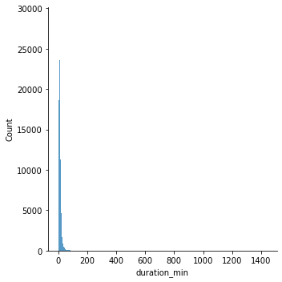

```python
# Initial exploration: how is the duration distributed throughout history?
sns.displot(data=master_clean, x='duration_min');
```

As we can see, the distribution has a huge hump in the beginning but an extraordinarily long tail at the end indicating that the data is extremely unevenly distributed across a long range. So next, let's check these extreme values and focus attention on the most common ones. As follows we utilize percentiles.

```python
# Calculate the percentiles of `duration_min`
master_clean.duration_min.describe(percentiles=[0, .25, .5, .75, .9, .95, .99])
```

```
count    2.996732e+06
mean     1.291235e+01
std      3.319408e+01
min      1.016667e+00
0%       1.016667e+00
25%      5.750000e+00
50%      9.033333e+00
75%      1.393333e+01
90%      2.078333e+01
95%      2.738333e+01
99%      6.395000e+01
max      1.438017e+03
Name: duration_min, dtype: float64
```

As above, **50%** of the data (namely **Q1-Q3**) are in the range of **5.75 - 13.9 minutes**; **95%** of the data fall within **27.3 minuets**; **99%** of the data fall within **63.95 minutes**, approximately **1 hour**, while the maximum values goes up to **1438 minutes**, about **24 hours**, unbelievable!

In the following, I will mainly focus on **99%** of the duration values or values less than **64 minutes**.

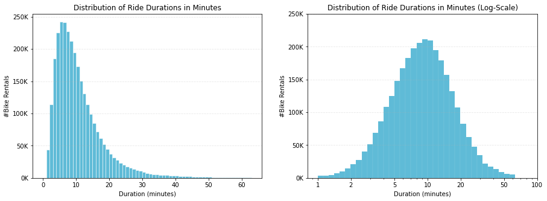

```python
# Set  size of canvas
plt.figure(figsize=(15, 5))

# Plot on the left
plt.subplot(1, 2, 1)
sns.histplot(x=master_clean['duration_min'], \
            bins=np.arange(0, 64, 1), \
            edgecolor="white", \
            color=base_color)
plt.grid(axis='y', linestyle='--', alpha=.3)
orig_ticks = np.arange(0, 300_000, 50_000)
new_ticks = ["{}K".format(int(i/1000)) for i in orig_ticks]
plt.yticks(orig_ticks, new_ticks)

plt.title('Distribution of Ride Durations in Minutes')
plt.xlabel('Duration (minutes)')
plt.ylabel('#Bike Rentals');

# Plot on the right
plt.subplot(1, 2, 2)
# Histogram under `log` scale
sns.histplot(x=master_clean['duration_min'], \
            bins=10**np.arange(0, np.log10(64), .05), \
            edgecolor="white", \
            color=base_color)

# Change the x axis on log-scale
plt.xscale('log')

plt.grid(axis='y', linestyle='--', alpha=.3)
orig_ticks = np.arange(0, 300_000, 50_000)
new_ticks = ["{}K".format(int(i/1000)) for i in orig_ticks]
plt.yticks(orig_ticks, new_ticks)

# Map the x ticks on the axis
ticks = np.array([1, 2, 5, 10, 20, 50, 100])
plt.xticks(ticks, ["{}".format(i) for i in ticks])

# Set title, x-label and y-label
plt.title('Distribution of Ride Durations in Minutes (Log-Scale)')
plt.xlabel('Duration (minutes)')
plt.ylabel('#Bike Rentals');
```

**Insights for Distribution of Duration Time**

From the histogram **on the left**, we can see that the duration time is a right-skewed distribution. If we put it on a log-scale, **see on the right**, we can get an almost perfect normal distribution.

- Half of the duration time for a ride fall bewteen **5.75 mins (Q1) and 13.9 mins (Q3)** with average value being **12.9 mins**.
- **95%** of the data fall within **27.3 minuets** and **99%** of the data fall within **63.95 minutes**.
- **Extreme values** can go up to as large as **1438 minutes** (< 1%).
- The distribution pattern seems to be aligned with the [policy](https://www.lyft.com/bikes/bay-wheels/pricing) saying *Membership includes the first 45 minutes of each trip for free; Rides longer than **45 minutes** are $2 for each additional 15 minutes*. It seems to reveals that each user is really an [economic man](https://en.wikipedia.org/wiki/Homo_economicus).

### Univaraite Exploration 2.What does the distribution of distance for a ride look like?

```python
master_clean.trip_distance_km.describe(percentiles=[0, .1, .2, .25, .5, .75, .9, .95, .99, .9999])
```

```
count     2.996732e+06
mean      1.632535e+00
std       1.041956e+00
min       0.000000e+00
0%        0.000000e+00
10%       5.870483e-01
20%       7.922671e-01
25%       8.906359e-01
50%       1.402810e+00
75%       2.131811e+00
90%       3.050871e+00
95%       3.667879e+00
99%       4.900059e+00
99.99%    8.647677e+00
max       6.946598e+01
Name: trip_distance_km, dtype: float64
```

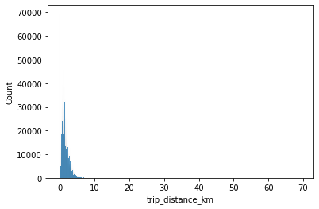

```python
sns.histplot(data=master_clean, x='trip_distance_km')
```

It demonstrates the similar pattern with `duration_min`, so next I rescale the x axis on log for better visualization.

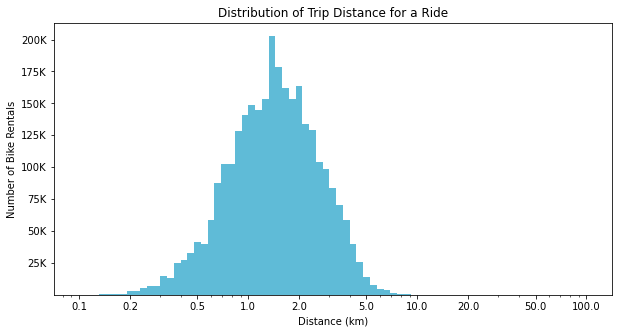

```python
## distance_df = master_clean[master_clean.trip_distance_km>1]

# Set propertites for the bin edges
lower_limit = -1
upper_limit = 2
interval = 0.04

# Define bin edges
bin_edges = 10 ** np.arange(lower_limit, upper_limit+interval, interval)

# Create figure object
plt.figure(figsize=fig_size)

# Create histogram
sns.histplot(data=master_clean, x='trip_distance_km', bins=bin_edges, color=base_color, edgecolor='white')
plt.xscale('log');

# Reset x ticks for readibility and interpretability
x_ticks = np.array([.1, .2, .5, 1, 2, 5, 10, 20, 50, 100])
plt.xticks(x_ticks, ["{}".format(i) for i in x_ticks])

# Reset y ticks for readibility and interpretability
y_ticks_old = range(25000, 225000, 25000)
plt.yticks(y_ticks_old, ["{}K".format(int(i/1000)) for i in y_ticks_old])

# Add x and y label
plt.xlabel("Distance (km)")
plt.ylabel("Number of Bike Rentals")

# Add title
plt.title("Distribution of Trip Distance for a Ride");
```

**Insight for Distribution of Trip Distance for a Ride**

- When the x axis (distance) is scaled in log, the histogram presents a **bell-like shape** which implies it has a long right tail.
- Almost **99.99%** of the trip distance is within **9km**, although some extreme values extends to 69km.
- Trip distance between **1km and 2km** is more common, on either side of which however the number of rentals decreases sharply on a log scale.

### Univariate Exploration 3.How are the users in different ages distributed?

Let's take a quick view by `.value_counts()` function on the `age_range` feature.

```python
master_clean.age_range.value_counts().sort_index()
```

```
(10.0, 20.0]      37460
(20.0, 30.0]    1014602
(30.0, 40.0]    1173074
(40.0, 50.0]     472267
(50.0, 60.0]     249573
(60.0, inf]       49756
Name: age_range, dtype: int64
```

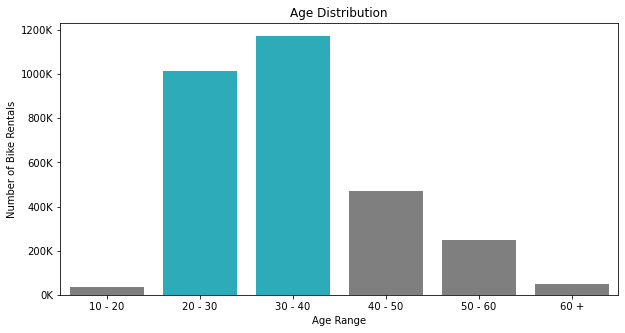

```python
# Set figure size
plt.figure(figsize=fig_size)

# Construct dataframe for coloring purpose
cnts = master_clean.age_range.value_counts().sort_index().values

# Plotting
sns.countplot(data=master_clean, \
              x='age_range', \
              palette=[sns.color_palette()[-1] if val > 1_000_000 else sns.color_palette()[-3] for val in cnts])

# Reset x ticks
plt.xticks(range(6), ['10 - 20', '20 - 30', '30 - 40', '40 - 50', '50 - 60', '60 +'])

# Reset y ticks for readibility and interpretability
y_ticks_old = [0, 0.2e6, .4e6, .6e6, .8e6, 1e6, 1.2e6]
plt.yticks(y_ticks_old, ["{}K".format(int(i/1000)) for i in y_ticks_old])

# Set title, x and y label
plt.title("Age Distribution")
plt.xlabel('Age Range')
plt.ylabel("Number of Bike Rentals");
```

As can be seen from above, age between **20 to 40** contributes the most users of all with **30-40** being the peak. And **10-20** and **60+** have the least users.

We can use **histogram** and **violin plots** to take a deeper look with more flexibility into how member ages are distributed as follows.

```python
# Summary statistics on `member_age`
master_clean.member_age.describe()
```

```
count    2.996732e+06
mean     3.552525e+01
std      9.725393e+00
min      1.800000e+01
25%      2.800000e+01
50%      3.300000e+01
75%      4.100000e+01
max      6.600000e+01
Name: member_age, dtype: float64
```

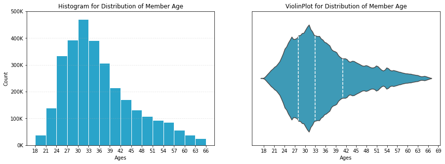

```python
# Set  size of canvas
plt.figure(figsize=(15, 5))

# Draw hisrogram on the left
plt.subplot(1, 2, 1)
bins_interval = 3
bin_edges = range(master_clean.member_age.min(), master_clean.member_age.max()+bins_interval, bins_interval)

plt.hist(master_clean.member_age, bins=bin_edges, edgecolor='white', color=base_color)

plt.grid(axis='y', linestyle='--', alpha=0.3)

orig_ticks = bin_edges
new_ticks = orig_ticks
plt.xticks(orig_ticks, new_ticks)

orig_ticks = np.arange(0, 600_000, 100_000)
new_ticks = ["{}K".format(int(i/1000)) for i in orig_ticks]
plt.yticks(orig_ticks, new_ticks);

plt.title('Histogram for Distribution of Member Age')
plt.xlabel('Ages')
plt.ylabel('Count')


# Draw violin plot on the left
plt.subplot(1, 2, 2)
ax = sns.violinplot(data=master_clean, x='member_age', color=base_color, inner='quartile', )

# Set quartile properties in ViolinPlot
for l in ax.lines:
    l.set_linestyle('--')
    l.set_color('white')

# Set x and y ticks
x_ticks_old = np.arange(18, 70, 3)
plt.xticks(x_ticks_old, ["{}".format(int(i)) for i in x_ticks_old])
plt.yticks([])

# Add title and x label
plt.title('ViolinPlot for Distribution of Member Age')
plt.xlabel('Ages');
```

### Univariate Exploration 4. How are users with different genders distributed?

I defined a function to draw veritical bar plots for studying the distribution behavior of features like `user_gender`, `user_type` and `bike_share_for_all_trip` because the whole process from this on is quite similar to each other as well as following the **DIY or Don't Repeat Yourself Principle**.

```python
def vertical_bar_plots(col, \
                       x_label, \
                       title_, \
                       y_min, \
                       y_max, \
                       interval, \
                       y_label='Number of Bike Rentals', \
                       pct_text_alignment=50_000, \
                       y_tick_unit='M'):

    """Plot bar charts with relative percentage annotation on categorical data"""

    # Calculate counts for each component under a categorical feature
    each_counts = master_clean[col].value_counts(sort=False)

    # Make count plot based on the categorical feature
    sns.countplot(data=master_clean, x=col, color=base_color)

    # Add dashed line for reading data easily in the plot
    plt.grid(axis='y', linestyle='--', alpha=.3)

    # Add relative frequency text for each
    total_counts = master_clean.shape[0]

    for i in range (each_counts.shape[0]):
        counts = each_counts[i]
        pct_string = '{:.2f}%'.format(100*counts/total_counts)
        plt.text(i, counts+pct_text_alignment, pct_string, ha='center')

    # Change unit representation on y ticks
    if y_tick_unit == 'M':
        # Change y tick scale from 1,000,000 to 1M
        orig_ticks = np.arange(y_min, y_max, interval)
        new_ticks = ["{}M".format(i/1000000) for i in orig_ticks]
        plt.yticks(orig_ticks, new_ticks)

    elif y_tick_unit == 'K':
        # Change y tick scale from 1,000 to 1K
        orig_ticks = np.arange(y_min, y_max, interval)
        new_ticks = ["{}K".format(int(i/1000)) for i in orig_ticks]
        plt.yticks(orig_ticks, new_ticks)

    # Add label for x and y axis
    plt.xlabel(x_label)
    plt.ylabel(y_label)

    # Add title
    plt.title(title_, fontdict={'fontsize':13}, pad=10);
```

```python
# Print out the counts of users based on their gender classification
counts_by_gender = master_clean['member_gender'].value_counts(sort=False)
print(counts_by_gender)
```

```
Male      2218648
Female     729176
Other       48908
Name: member_gender, dtype: int64
```

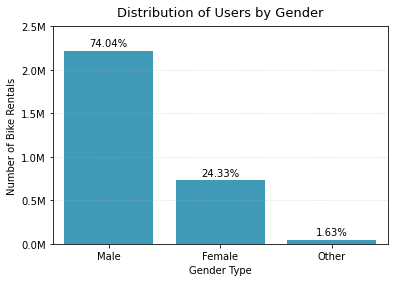

```python
vertical_bar_plots(col='member_gender', \
                   x_label='Gender Type', \
                   title_='Distribution of Users by Gender', \
                   y_min=0,
                   y_max=3_000_000,
                   interval=500_000)
```

**Insight for Distribution of Users by Gender**

- **Male** users play a dominant role, covering **74%** or **2.2 million** of bike rental users.
- **Female** users covers slightly less than **1/4** of bike rental users.
- Users gender classfied as **Other** have the least numbers, only covering **1.6%** of the whole.

We can study more on *"how gender affects the usage of bicycles?"* in the bivariate and multi-variate exploration part.

### Univariate Exploration 5. How are the users in different user types distributed?

```python
# Print out counts summary
master_clean.user_type.value_counts()
```

```
Subscriber    2655635
Customer       341097
Name: user_type, dtype: int64
```

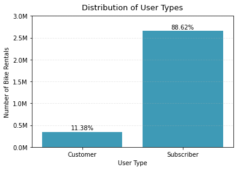

```python
vertical_bar_plots(col='user_type', \
                   x_label='User Type', \
                   title_='Distribution of User Types', \
                   y_min=0,
                   y_max=3_500_000,
                   interval=500_000)
```

**Insight for Distribution of Users by User Type**

- There are **two** user types in data - `Customer` and `Subscriber`.
- The differences between these two types is obvious and the gap in bewteen is so huge that the number of **subscribers** is almost as **8** times as that of **customers**. The reason for this maybe because being a subscriber can bring more benefits such as less pricing, additional coupons, better service etc.

*Will the usage behavior in these two groups differe a lot?* We can study more on this in the bivariate or multi-variate exploration part.

### Univariate Exploration 6. Distribution of Users by *Bike-Share-for-All-Trip* Selection.

```python
master_clean.bike_share_for_all_trip.value_counts()
```

```
No     2315837
Yes     233366
Name: bike_share_for_all_trip, dtype: int64
```

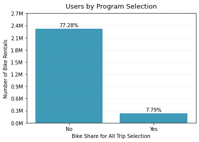

```python
vertical_bar_plots(col='bike_share_for_all_trip', \
                   x_label='Bike Share for All Trip Selection', \
                   title_='Users by Program Selection', \
                   y_min=0,
                   y_max=3_000_000,
                   interval=300_000)
```

**Insight for Distribution of Users by Program Selection**

- Unexpectedly, the number of people choosing `bike_share_for_all_trip` program is far less than those who don't, covering less than **8%** of the whole user population. According to the [introduciton](https://www.lyft.com/bikes/bay-wheels/pricing) to the `bike_share_for_all_trip`, there seems to be a reason that some restrictions are included for applying for this program such as income, payment method (*only support pay by year*), so the number of people who would like to join this program could be less.

### Univariate Exploration 7. Bike Rentals Trend by Month

In the following, I will explore what the trend is like for the bike rentals from **June 2017 to April, 2019**.

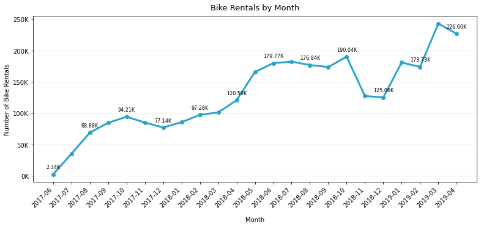

```python
month_df = master_clean.resample('M', on='start_time').bike_id.count().to_frame().reset_index()
month_df.start_time = month_df.start_time.astype(str)

plt.figure(figsize=(13, 5))
plt.plot(month_df['start_time'].str.slice(0, 7), \
         month_df.bike_id, \
         color=base_color, \
         linewidth=3, \
         marker='o')

plt.grid(axis='y', alpha=0.3)

plt.xticks(rotation=45, ha='right')

# Add label for x and y axis
plt.xlabel("Month", labelpad=13)
plt.ylabel("Number of Bike Rentals")

# Change the unit representation for y ticks
orig_ticks = np.arange(0, 300_000, 50_000)
new_ticks = ["{}K".format(int(i/1000)) for i in orig_ticks]
plt.yticks(orig_ticks, new_ticks)

# Add relative frequency as text on the plot
for i in range (month_df.shape[0]):
    counts = month_df.iloc[i, 1]
    if i % 2 == 0:
        pct_string = '{:.2f}K'.format(counts/1000)
        plt.text(i, counts+9000, pct_string, ha='center', fontdict={'fontsize':8})

# Add title
plt.title("Bike Rentals by Month", fontdict={'fontsize':13}, pad=10);
```

**Insight on Bike Rentals Trend by Year-Month**

### Univariate Exploration 8. Distribution of Bike Rentals by Day in a Week

```python
# Print out the counts summary
master_clean.start_time_dow.value_counts()
```

```
Tue    519109
Thu    517871
Wed    511976
Mon    476083
Fri    472766
Sat    265408
Sun    233519
Name: start_time_dow, dtype: int64
```

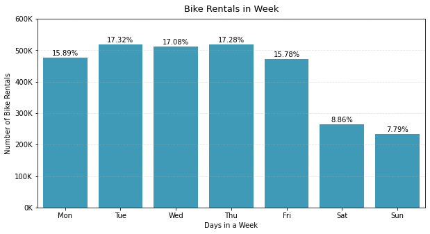

```python
# Set figure size
plt.figure(figsize=fig_size)

# Plotting
vertical_bar_plots(col='start_time_dow', \
                   x_label='Days in a Week', \
                   title_='Bike Rentals in Week', \
                   y_min=0,
                   y_max=650_000,
                   interval=100_000, \
                   pct_text_alignment=7000, \
                   y_tick_unit='K')
```

- The result shows clearly that bike rentals on weekdays are far more than that at the weekends, almost **2 times** as large.
- During weekdays, bike rentals happen the most on *Tuesday, Wednesday and Thursday*, with very close percentage, while rentals on *Monday and Friday* are another group that shares similar percentage but as lower as about **2 percentage point** than that of the former one.

### Univariate Exploration 9. Distribution of Bike Rentals in Different Hours of a Day.

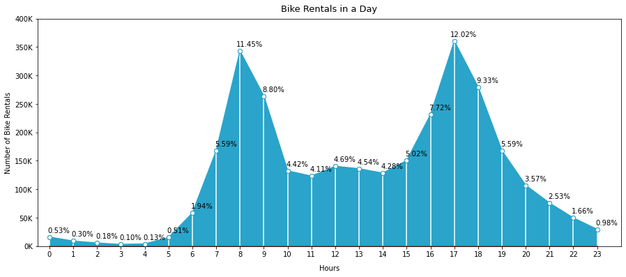

```python
# Construct the dataframe for plotting
## Calculate the counts by hours in a day
vals_hours_counts = master_clean.start_time_hour.value_counts().sort_index()
idx_hours_counts = master_clean.start_time_hour.value_counts().sort_index().index

#
plt.figure(figsize=(15, 6))

# Plot a vertical line between point on curve and x axis
plt.stem(idx_hours_counts, vals_hours_counts, linefmt='white')

# Draw line plot with markers
plt.plot(vals_hours_counts, marker='o', markerfacecolor='white', color=base_color)


# Fill color between
plt.fill_between(idx_hours_counts, vals_hours_counts, color=base_color, )

# Calculate counts for each component under a categorical feature
each_counts = master_clean['start_time_hour'].value_counts(sort=False)

# Add relative frequency text for each
total_counts = master_clean.shape[0]

# Add relative frequency as text on the plot
for i in range (each_counts.shape[0]):
    counts = each_counts[i]
    pct_string = '{:.2f}%'.format(100*counts/total_counts)
    plt.text(i+.4, counts+8000, pct_string, ha='center')

# Change the unit representation for y ticks
orig_ticks = np.arange(0, 450_000, 50_000)
new_ticks = ["{}K".format(int(i/1000)) for i in orig_ticks]
plt.yticks(orig_ticks, new_ticks)

# Set x ticks and label on the x axis
plt.xticks(range(0, 24))
plt.xlabel('Hours', labelpad=10)
plt.ylabel('Number of Bike Rentals')

# Change the x and y limit and margins for visual purpose
plt.xlim((-.5, 24))
plt.ylim((0, 400_000))
plt.margins(y=0)

# Set the title for the plot
plt.title('Bike Rentals in a Day', fontdict={'fontsize':13}, pad=10);
```

**Insight on Bike Rentals Trend in Different Hours of a Day**

- As can be seen from above, there are two apparent **humps** in the graph: **7:00 - 9:00 in the morning** and **16:00 - 19:00 in the evening**, a.k.a. the *rush hours*, and the period of rush hour in the evening seems a little bit longer than that in the moring as it presents wider hump in the graph.
- During the *office hours*, namely the period between 10:00 and 14:00, the rental percentage is only 1/3 or 1/2 of that in the peak period.
- We may guess that the dominant users for the bike rentals are from working class.

### Discuss the distribution(s) of your variable(s) of interest. Were there any unusual points? Did you need to perform any transformations?

> 1. `duration_min`, which is derived from the original `duration_sec`, is one of the variables of my interest. After calculating its percentiles, I found out that, **99%** of the data fall within **63.95 minutes**, approximately **1 hour**, while the maximum values goes up to **1438 minutes**, about **24 hours** which is unbelievable, so for studying the distribution pattern for most of the data, I **filtered out** those `duration_min` larger than **64 minutes** which covers less than **1%** of the whole data. Furthermore, when the `duration_min` was initially plotted using histogram, it presented a very long right tail. So I performed **log scale** on it and afterwards it presented approximately a normal distribution.
> 2. As for the `trip_distance_km`, it also presented a normal distribution when applied **log scale**. Although there is a seemingly-like outlier, e.g. 64km, as what I analyzed in the data wranging process, I decided to keep it.

### Of the features you investigated, were there any unusual distributions? Did you perform any operations on the data to tidy, adjust, or change the form of the data? If so, why did you do this?

> In the data wrangling process, I performed several outlier detection process and found out that the `member_age` feature did have some unusual values (**see age anomaly**). The maximum age can be as large as **141 y/o** while **99%** of age values lie before the age of 66, so I filtered out those data whose ages are beyond **66 y/o**.

> I also filtered out data whose `trip_distance_km` is larger than **100 km** (**_see distance anomaly in the data wrangling process_**) as the values larger than 100km can be as large as 10,000km which are obviously impossible for a bicycle ride in just less than 1 hour.

## Bivariate Exploration

### Bivairiate Exploration 1. How do the bike rentals vary with time among different user types?

```python
master_clean.info()
```

```
<class 'pandas.core.frame.DataFrame'>
RangeIndex: 2996732 entries, 0 to 2996731
Data columns (total 21 columns):
 #   Column                      Dtype
---  ------                      -----
 0   duration_sec                int64
 1   start_time                  datetime64[ns]
 2   start_station_id            object
 3   start_station_name          object
 4   end_station_id              object
 5   end_station_name            object
 6   bike_id                     object
 7   user_type                   category
 8   member_gender               category
 9   bike_share_for_all_trip     category
 10  start_time_year             int64
 11  start_time_year_month       period[M]
 12  start_time_year_month_date  period[D]
 13  start_time_month            int64
 14  start_time_date             int64
 15  start_time_dow              category
 16  start_time_hour             int64
 17  member_age                  int64
 18  duration_min                float64
 19  trip_distance_km            float64
 20  age_range                   category
dtypes: category(5), datetime64[ns](1), float64(2), int64(6), object(5), period[D](1), period[M](1)
memory usage: 380.1+ MB
```

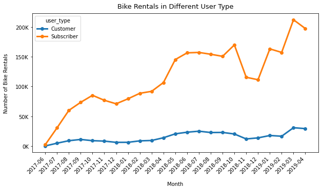

```python
# Construct the dataframe for plotting
df_yearMonth_userType = master_clean.groupby(['start_time_year_month', 'user_type']).size().reset_index()
df_yearMonth_userType.rename(columns={0: 'counts'}, inplace=True)

df_yearMonth_userType = df_yearMonth_userType.pivot_table(values='counts',
                                index='start_time_year_month',
                                columns='user_type')


df_yearMonth_userType.index = df_yearMonth_userType.index.astype(str)

# df_yearMonth_userType

# Line plot with marker
df_yearMonth_userType.plot(marker='o', figsize=fig_size, linewidth=3)

# Change x ticks to improve readibility
plt.xticks(range(23), list(df_yearMonth_userType.index), rotation=45, ha='right');

# Change the unit representation for y ticks
orig_ticks = np.arange(0, 250_000, 50_000)
new_ticks = ["{}K".format(int(i/1000)) for i in orig_ticks]
plt.yticks(orig_ticks, new_ticks)

# Add label for x and y axis
plt.xlabel("Month", labelpad=13)
plt.ylabel("Number of Bike Rentals", labelpad=13)

# Add title
plt.title("Bike Rentals in Different User Type", fontdict={'fontsize':13}, pad=10);
```

#### Insight on the bike rentals for different user types

- The users with **Subscriber** type present similar trend to the general trend we found earlier in univariate exploration : the **seasonal trend** (see here), while for **Customer** user type, it does not show much change with time.

### Bivairiate Exploration 2. How do the bike rentals vary with time among different genders?

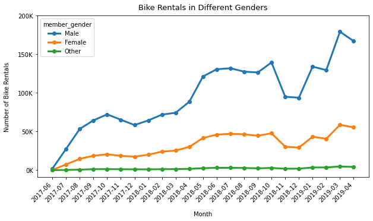

```python
# Construct the dataframe for plotting
df_yearMonth_gender = master_clean.groupby(['start_time_year_month', 'member_gender']).size().reset_index()
df_yearMonth_gender.rename(columns={0: 'counts'}, inplace=True)

df_yearMonth_gender = df_yearMonth_gender.pivot_table(values='counts',
                                index='start_time_year_month',
                                columns='member_gender')


df_yearMonth_gender.index = df_yearMonth_gender.index.astype(str)


# Line plot with marker
df_yearMonth_gender.plot(marker='o', figsize=fig_size, linewidth=3)

# Change x ticks to improve readibility
plt.xticks(range(23), list(df_yearMonth_gender.index), rotation=45, ha='right');

# Change the unit representation for y ticks
orig_ticks = np.arange(0, 250_000, 50_000)
new_ticks = ["{}K".format(int(i/1000)) for i in orig_ticks]
plt.yticks(orig_ticks, new_ticks)

# Add label for x and y axis
plt.xlabel("Month", labelpad=13)
plt.ylabel("Number of Bike Rentals", labelpad=13)

# Add title
plt.title("Bike Rentals in Different Genders", fontdict={'fontsize':13}, pad=10);
```

#### Insight on the bike rentals for different user gender types

- The **Male and Female** users also present similar trend to the general trend we found earlier in univariate exploration : the **seasonal trend** (see here) although the trend for **Female** users are weaker, while for users in **Other** gender, it number of rentals is relatively **steady** with time.

### Bivariate Exploration 3. Rental pattern for users in `bike_share_for_all_trip` program or not.

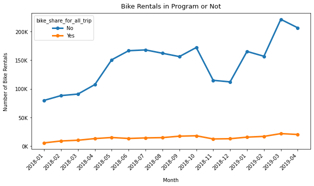

```python
# Only select the data when the program initiated
df_yearMonth_program = master_clean[master_clean.bike_share_for_all_trip.notnull()]

groupby_condition = ['start_time_year_month', 'bike_share_for_all_trip']
df_yearMonth_program = df_yearMonth_program.groupby(groupby_condition).size().reset_index()
df_yearMonth_program.rename(columns={0: 'counts'}, inplace=True)

df_yearMonth_program = df_yearMonth_program.pivot_table(values='counts',
                                index='start_time_year_month',
                                columns='bike_share_for_all_trip')

df_yearMonth_program.index = df_yearMonth_program.index.astype(str)


# Line plot with marker
df_yearMonth_program.plot(marker='o', figsize=fig_size, linewidth=3)

# Change x ticks to improve readibility
plt.xticks(range(16), list(df_yearMonth_program.index), rotation=45, ha='right');

# Change the unit representation for y ticks
orig_ticks = np.arange(0, 250_000, 50_000)
new_ticks = ["{}K".format(int(i/1000)) for i in orig_ticks]
plt.yticks(orig_ticks, new_ticks)

# Add label for x and y axis
plt.xlabel("Month", labelpad=13)
plt.ylabel("Number of Bike Rentals", labelpad=13)

# Add title
plt.title("Bike Rentals in Program or Not", fontdict={'fontsize':13}, pad=10);
```

#### Insight on the bike rentals for program selection

- The users *not choosing* the `bike_share_for_all_trip` program present similar trend to the general trend we found earlier in univariate exploration : the **seasonal trend** (see here), while for those who *choose*, do not show much change with season but a relatively steady increasing trend.

### Bivariate Exploration 4. How do the bike rentals vary with time for different age ranges?

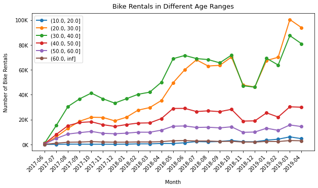

```python
df_yearMonth_age = master_clean.groupby(['start_time_year_month', 'age_range']).size().reset_index()
df_yearMonth_age.rename(columns={0: 'counts'}, inplace=True)

df_yearMonth_age = df_yearMonth_age.pivot_table(values='counts',
                                index='start_time_year_month',
                                columns='age_range')


df_yearMonth_age.index = df_yearMonth_age.index.astype(str)

# df_yearMonth_userType

# Line plot with marker
df_yearMonth_age.plot(marker='o', figsize=fig_size, linewidth=2)

# Change x ticks to improve readibility
plt.xticks(range(23), list(df_yearMonth_age.index), rotation=45, ha='right');

# Change the unit representation for y ticks
orig_ticks = np.arange(0, 120_000, 20_000)
new_ticks = ["{}K".format(int(i/1000)) for i in orig_ticks]
plt.yticks(orig_ticks, new_ticks)

# Add label for x and y axis
plt.xlabel("Month", labelpad=13)
plt.ylabel("Number of Bike Rentals", labelpad=13)

# Add title
plt.title("Bike Rentals in Different Age Ranges", fontdict={'fontsize':13}, pad=10)

plt.legend(loc='upper left');
```

#### Insight on bike rentals trend in different age range

The graph above shows that

- The majority of users are between **20 - 40 years old**.
- **(10, 20] group** and **(60, inf) group** do not show much change with time, while the other groups show again the **seasonal trend** to some extent, i.e. for groups of **(20, 30], (30, 40], (50, 60]**, this pattern is obvious and strong especially in users with age range of **(20, 30] and (30, 40] y/o**.
- Users in **(20, 30]** group climb up fast since 2018-04 and surpass the number of users in **(30, 40]** group the first time in 2018-11.

### Bivariate Exploration 5. How Are Ride Duration Time and Distance Distributed in Diffferent Days of a Week?

**I. Duration time distribution in days of a week**

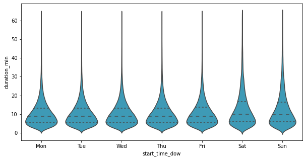

```python
plt.figure(figsize=fig_size)

# Plot violin plot for showing the distribution duration time in days of a week
sns.violinplot(data=master_clean[master_clean.duration_min < 64], \
               x='start_time_dow', \
               y='duration_min', \
               color=base_color, inner='quartile');
```

**Insight**

- There is **not that much differnece** in term of duration time for a trip, especially from **Monday to Friday**, while on **Saturday** and **Sunday** the median and third quartile is slightly larger than that of the rest, as well as with more varying time range as the shape becomes thinner and longer.

We can be more confirmed by calculating the average `duration_min` varying along with time in *Multi-variate Exploration Part*.

**II. Trip disrance distribution in days of a week**

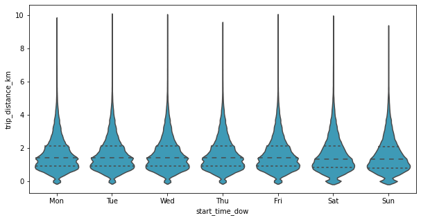

```python
plt.figure(figsize=fig_size)

# Plot violin plot for showing the distribution trip distance for a ride in days of a week
sns.violinplot(data=master_clean[master_clean.trip_distance_km < 10], \
               x='start_time_dow', \
               y='trip_distance_km', \
               color=base_color, inner='quartile');
```

**Insight**

- In terms of trip distance for a ride, the differnce is much less varied in days of a week, compared with the duration time distribution.
- This may not be a clear way to study on the `duration time` and `distance` features and I will calculate their averages to take a further research on the variations with time in the *Multivariate Exploration Part*.

### Bivariate Exploration 6. Average duration time and trip distance distribution in ages.

```python
# aggregate avergae duration based on age
master_clean.groupby('member_age').duration_min.mean()
```

```
member_age
18    26.655702
19    17.303206
20    15.126442
21    14.964233
22    13.993681
23    13.774252
24    13.207604
25    12.923314
26    12.366969
27    13.307848
28    12.706966
29    13.013177
30    13.049320
31    12.672686
```

[output cut: 36 more lines]

```python
# aggregate avergae duration based on age
master_clean.groupby('member_age').trip_distance_km.mean().describe()
```

```
count    49.000000
mean      1.583987
std       0.110051
min       1.236528
25%       1.516691
50%       1.610584
75%       1.671602
max       1.764289
Name: trip_distance_km, dtype: float64
```

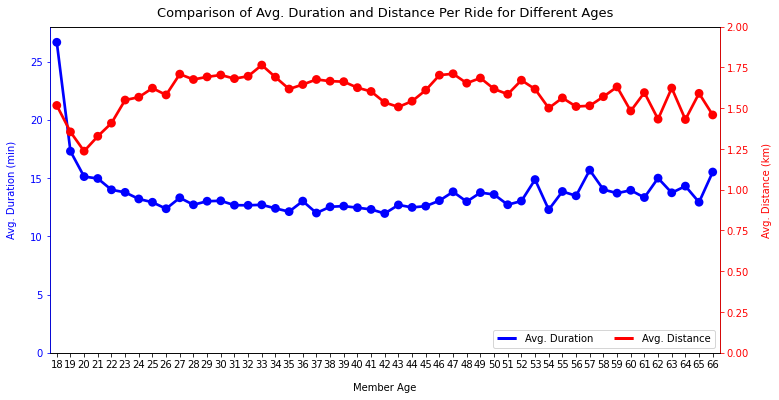

```python
from matplotlib.lines import Line2D

fig, ax1 = plt.subplots(figsize=(12, 6))

# Two axes share the same x axis
ax2 = ax1.twinx()

# Make the avg.distance curve, colored in 'blue'
sns.pointplot(data=master_clean, \
              x='member_age', \
              y='duration_min', \
              color='blue', \
              ci=None, \
              ax=ax1)


# Make the avg.distance curve, colored in 'red'
sns.pointplot(data=master_clean, \
              x='member_age', \
              y='trip_distance_km', \
              ci=None, \
              color='red', \
              ax=ax2);

# Add legend to each curve
colors = ['blue', 'red']
lines = [Line2D([0], [0], color=c, linewidth=3, linestyle='-.') for c in colors]
labels = ['Avg. Duration', 'Avg. Distance']
plt.legend(lines, labels, ncol=2, loc='lower right')

# Customize properties of the x label
ax1.set_xlabel('Member Age', labelpad=13, fontsize=10)

# Customize y label properties for ax1
ax1.set_ylabel('Avg. Duration (min)', color='blue', labelpad=13, fontsize=10)
ax1.tick_params(axis='y', colors='blue')
ax1.set_ylim(0, 28)

# Customize y label properties for ax2
ax2.set_ylabel('Avg. Distance (km)', color='red', labelpad=13, fontsize=10)
ax2.spines['left'].set_color('blue')
ax2.tick_params(axis='y', colors='red')
ax2.spines['right'].set_color('red')
ax2.set_ylim(0, 2)

# Add title
plt.title("Comparison of Avg. Duration and Distance Per Ride for Different Ages", fontdict={'fontsize':13}, pad=10);
```

#### Insights:

**We can take a deeper look into how the average duration time varies among different ages, even considering some other factors like user types, user gender and time, in the multivariate exploration.**

### Talk about some of the relationships you observed in this part of the investigation. How did the feature(s) of interest vary with other features in the dataset?

> WHE **user type** is considered, there is an obvious difference for the trend between **Subscriber** and **Customer** group. For **Subscribers**, the general trend for relationship between number of rentals and year-month is increasing as time goes by. At the beginning of 2017-06, there are only **2K**, however after **23 months**, the total number mounts up to **220K**, almost **100 times** larger. *Interestingly*, it also presents a **seasonal pattern** as winter comes in and temperature is low, the rentals are going down, while in pleasing climate like spring and summer with cozy weather conditions, the rentals are up. However, users with **Customer** type do not present so much strong pattern as **Subscribers**.

> When taking **genders** and **bike share for all trip program** into consideration, it is clear that **Males** and **those who do not** invovle with the **program** lead the number of rentals with time. Furthermore, it also exhibit a similar **seasonal trend** to the total rentals as a whole. (**_See here_**)

> When I put the distribution of duration time and trip distance per ride on violinplots throughout days of a week, it seems that the median and interquartiles for the **trip distance per ride** is almost **the same** (*See here*)). Only the median and interquartile for the **duration time** are showing slight differences at the weekends (**larger and more varied**) than that on weekdays. (*See here*)

### Did you observe any interesting relationships between the other features (not the main feature(s) of interest)?

> **Subscriber** in `user_type`, **Male** in `member_gender`, **No(non-member)** in `bike_share_for_all_trip` and **20-40 y/o** users in `age_range` exhibit similar patterns (**increasing and seasonal pattern**) in terms of their contributing to the rentals with time. Other sub-categories show less or don't.

## Multivariate Exploration

### Mutivariate Exploration 1. How are the duration time and trip distance distributed in days of a week by different genders?

#### I. Duaration Time v.s. Day of a Week in Different Gender

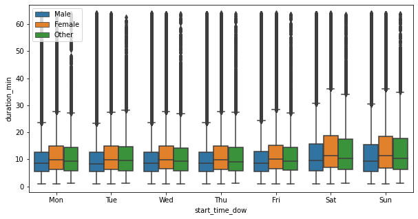

```python
plt.figure(figsize=fig_size)
sns.boxplot(data=master_clean[master_clean.duration_min < 64], \
            x='start_time_dow', \
            y='duration_min', \
            hue='member_gender')

plt.legend(loc='upper left');
```

#### Insights

- For all days in a week, the interquartile range for **Males** is always located the lowest compared with the other two gender types while **Female** the top, indicating that **Males** generally spend least time for a trip while **Females** the longest.
- It's clear that for all days in a week, the median of the duration time for a trip in **Female** is always the longest compared with the other two, while **Males** have the shortest.
- The difference of interquartile range bewteen **Female** and **Other** is smaller than that between **Female** and **Male**, or it is more similar with each other in terms of the duration time spent by **Female** and **Other** gender type.

We can take a deeper look into how the average duration time varies with time for different user genders in the *multivariate exploration 3*.

#### II. Trip Disrance v.s. Day of a Week in Different Gender

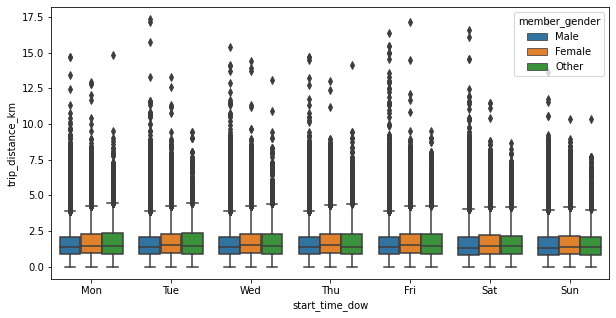

```python
plt.figure(figsize=fig_size)
sns.boxplot(data=master_clean[master_clean.trip_distance_km < 20], \
            x='start_time_dow', \
            y='trip_distance_km', \
            hue='member_gender');
```

**Insights**

- In terms of trip distance taken in days of a week by different gender types, it behaves similar pattern as in duration time, that is, the median of distance per ride for **Males** is always the shortest, while **Females** have the longest or as close to as the **Other** gender type. However, the differences among these three gender types are small.

We can take a deeper look into how the average trip distance varies with time for different user genders in the *multivariate exploration 3*.

### Mutivariate Exploration 2. How are the duration time and trip distance distributed in days of a week by different user types?

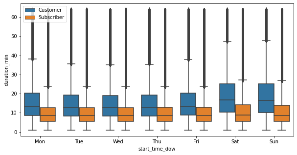

```python
plt.figure(figsize=fig_size)
sns.boxplot(data=master_clean[master_clean.duration_min < 64], \
            x='start_time_dow', \
            y='duration_min', \
            hue='user_type',
               )

plt.legend(loc='upper left');
```

#### Insights

- For all days in a week, the interquartile range for **Customer** user type is wider than that of **Subscriber**.
- For all days in a week, the median of the duration time takes for a ride by **Customer** user type is always longer than that of the **Subscriber**, and especially on **Saturday and Sunday**, the difference is even larger.
- On weekdays, namely from **Monday** to **Friday**, the interquartile range of duration time is almost the same within its own user type. However, at the weekends, the interquartile range of duration time is wider than that on weekdays, no matter which user type. It implies that people may haste for work at weekdays with short duration time while at the weekends, they are willing to spend longer time in a ride maybe just for leisures.

We can take a deeper look into how the average duration time varies with time for different user type in the *multivariate exploration 4*.

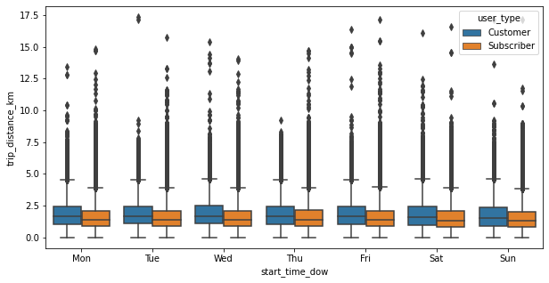

```python
plt.figure(figsize=fig_size)
sns.boxplot(data=master_clean[master_clean.trip_distance_km < 20], \
               x='start_time_dow', \
               y='trip_distance_km', \
            hue='user_type',
               )
```

#### Insights

- The interquartile range of distance for a ride is wider in **Customer** user type and the median is larger as well.
- There is not much difference throughout all days in a week for the interquartile range within its own user type.

We can take a deeper look into how the average trip distance varies with time for different user type in the *multivariate exploration 4*.

### Multi-variate Exploration 3. How do the average duration time and trip distance vary with time by different user genders?

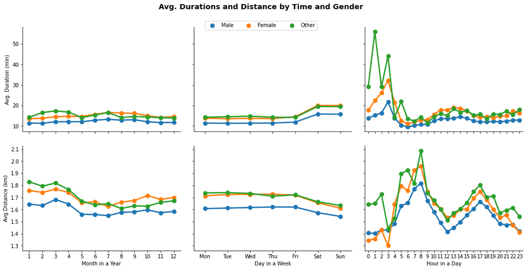

```python
num_vars = ['duration_min', 'trip_distance_km']
cat_vars = ['start_time_month', 'start_time_dow', 'start_time_hour']

g = sns.PairGrid(data = master_clean, \
                 x_vars = cat_vars, \
                 y_vars = num_vars, \
                 height = 2, \
                 aspect = 2, \
                 hue='member_gender')


g.map(sns.pointplot, ci=None, linewidth=.2)
g.fig.set_figheight(8)
g.fig.set_figwidth(15)

# g.add_legend()
handles = g._legend_data.values()
labels = g._legend_data.keys()
g.fig.legend(handles=handles, labels=labels, loc='upper center', ncol=3, bbox_to_anchor=(0, .93, 1, 0))


# Title for the complete figure
g.fig.suptitle("Avg. Durations and Distance by Time and Gender" ,
               fontsize = 'x-large' ,
               fontweight = 'bold' )

# Adjust subplots so that titles don't overlap
g.fig.subplots_adjust( top = 0.9 )

replacements = {'start_time_month': 'Month in a Year', 'start_time_dow': 'Day in a Week',
                'trip_distance_km': 'Avg.Distance (km)', 'petal_width': 'petal',
                'duration_min': 'Avg. Duration (min)', 'start_time_hour': 'Hour in a Day'}

# Customize axis labels
for i in range(2):
    for j in range(3):
        xlabel = g.axes[i][j].get_xlabel()
        ylabel = g.axes[i][j].get_ylabel()
        if xlabel in replacements.keys():
            g.axes[i][j].set_xlabel(replacements[xlabel])
        if ylabel in replacements.keys():
            g.axes[i][j].set_ylabel(replacements[ylabel]);
```

___Notice: the index of plots is numbered 0-based, from left to right and top to bottom.___

### Multi-variate Exploration 4. How do the average duration time and trip distance vary with time by different user types?

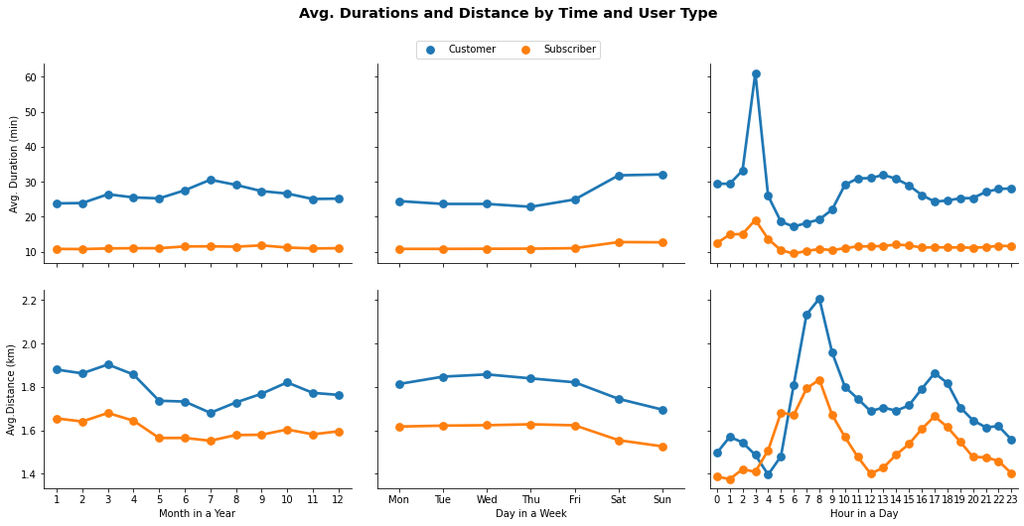

```python
num_vars = ['duration_min', 'trip_distance_km']
cat_vars = ['start_time_month', 'start_time_dow', 'start_time_hour']

g = sns.PairGrid(data = master_clean, \
                 x_vars = cat_vars, \
                 y_vars = num_vars, \
                 height = 2, \
                 aspect = 2, \
                 hue='user_type', \
                 palette='tab10')

g.map(sns.pointplot, ci=None, linewidth=.2)
g.fig.set_figheight(8)
g.fig.set_figwidth(15)

handles = g._legend_data.values()
labels = g._legend_data.keys()
g.fig.legend(handles=handles, labels=labels, loc='upper center', ncol=2, bbox_to_anchor=(0, .93, 1, 0))
# g.fig.subplots_adjust(top=.8, bottom=0)

# Title for the complete figure
g.fig.suptitle("Avg. Durations and Distance by Time and User Type" ,
               fontsize = 'x-large' ,
               fontweight = 'bold' )

# Adjust subplots so that titles don't overlap
g.fig.subplots_adjust( top = 0.88 )

replacements = {'start_time_month': 'Month in a Year', 'start_time_dow': 'Day in a Week',
                'trip_distance_km': 'Avg.Distance (km)', 'petal_width': 'petal',
                'duration_min': 'Avg. Duration (min)', 'start_time_hour': 'Hour in a Day'}

# Improve readibility for axis labels
for i in range(2):
    for j in range(3):
        xlabel = g.axes[i][j].get_xlabel()
        ylabel = g.axes[i][j].get_ylabel()
        if xlabel in replacements.keys():
            g.axes[i][j].set_xlabel(replacements[xlabel])
        if ylabel in replacements.keys():
            g.axes[i][j].set_ylabel(replacements[ylabel]);
```

#### Insights

- Both the average duration time and distance per ride for users in **Subscriber** type, tend to have lower values than that of the **Customer** user type, except for *plot(1, 2)*. During **4:00 and 5:00 am**, average distance for **Subscribers** surpasses the **Customer** user type for the first and only time.
- In terms of average duration time, the **Subscriber** user type seems to have more stable curves, compare with the **Customer** group.
- When zoomed in the scale of hours in a day, the curves tend to be more fluctuating, no matter it's average duration time or diatance. In *plot(0, 2)*, **7:00 - 10:00 in the morning**, the duration time difference between **Customer** and **Subscriber** becomes larger as average duration time in **Customer** is increasing while that in **Subscriber** is relatively stable.
- When zoomed in the scale of hours in a day, there are two obvious humps in terms of average distance for a ride (**See plot(1, 2)**). This trend is similar to what we have analyze in the **univariate exploration part 9.** That is, the humps tend to occur during the **rush hour in the morning** and **rush hour in the evening**.

___Notice: the index of plots is numbered 0-based, from left to right and top to bottom.___

### Multi-variate Exploration 5. How does the average duration time differ for different user gender and types?

```python
master_clean.groupby(['user_type', 'member_gender']).duration_min.mean()
```

```
user_type   member_gender
Customer    Male             24.893870
            Female           30.164666
            Other            25.594520
Subscriber  Male             10.726702
            Female           12.386627
            Other            13.660423
Name: duration_min, dtype: float64
```

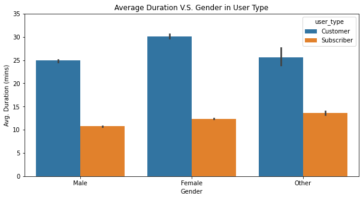

```python
plt.figure(figsize=fig_size)
sns.barplot(data=master_clean, \
              x='member_gender', \
              y='duration_min', \
              hue='user_type', \
              ci=95)

plt.xlabel('Gender')
plt.ylabel('Avg. Duration (mins)')
plt.title("Average Duration V.S. Gender in User Type")

plt.ylim(0, 35);
```

#### Insights

- The average duration time for a ride in users with **Subscriber** type is approximately only **1/2** of that in **Customer** user type, for all three genders.
- The average duration time difference in **Subscriber** user type is very close among three genders, compared with the **Customer** user type.
- In **Customer** user type, **Females** have the longest average duration time per ride. For **Males**, no matter what kind of user type they are, they tend to have the shortest average duration time per ride.

### Multi-variate Exploration 6. How does the average trip distance differ for different user gender and types?

```python
master_clean.groupby(['user_type', 'member_gender']).trip_distance_km.mean()
```

```
user_type   member_gender
Customer    Male             1.798208
            Female           1.794621
            Other            1.902760
Subscriber  Male             1.584577
            Female           1.691104
            Other            1.680356
Name: trip_distance_km, dtype: float64
```

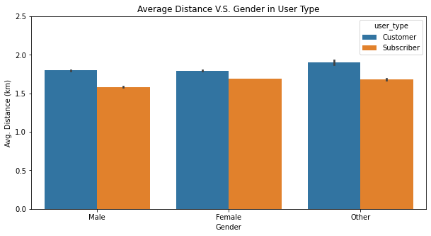

```python
plt.figure(figsize=fig_size)
sns.barplot(data=master_clean, \
              x='member_gender', \
              y='trip_distance_km', \
              hue='user_type', \
              ci=95)

plt.xlabel('Gender')
plt.ylabel('Avg. Distance (km)')
plt.title("Average Distance V.S. Gender in User Type")

plt.ylim(0, 2.5);
```

#### Insights

- **Subscribers in different gender type** have very close average distance per ride, so do the **Customer** user type.
- The average distance for the **Subscribers** are always shorter than that of **Customers**.
- **Male Subscriber** has the shortest average distance per ride while **Customer** users with **Other** gender type have the longest average distance per ride.

### Multi-Variate Exploration 7. What is the rental pattern for different user types based on days of a week v.s hours in a day?

```python
type_df = master_clean.groupby(['user_type', 'start_time_hour', 'start_time_dow']).bike_id.count().reset_index()
type_df
```

|  | user_type | start_time_hour | start_time_dow | bike_id |
| --- | --- | --- | --- | --- |
| 0 | Customer | 0 | Mon | 183 |
| 1 | Customer | 0 | Tue | 181 |
| 2 | Customer | 0 | Wed | 150 |
| 3 | Customer | 0 | Thu | 205 |
| 4 | Customer | 0 | Fri | 280 |
| ... | ... | ... | ... | ... |
| 331 | Subscriber | 23 | Wed | 3710 |
| 332 | Subscriber | 23 | Thu | 4240 |
| 333 | Subscriber | 23 | Fri | 4974 |
| 334 | Subscriber | 23 | Sat | 4191 |
| 335 | Subscriber | 23 | Sun | 2438 |

336 rows × 4 columns

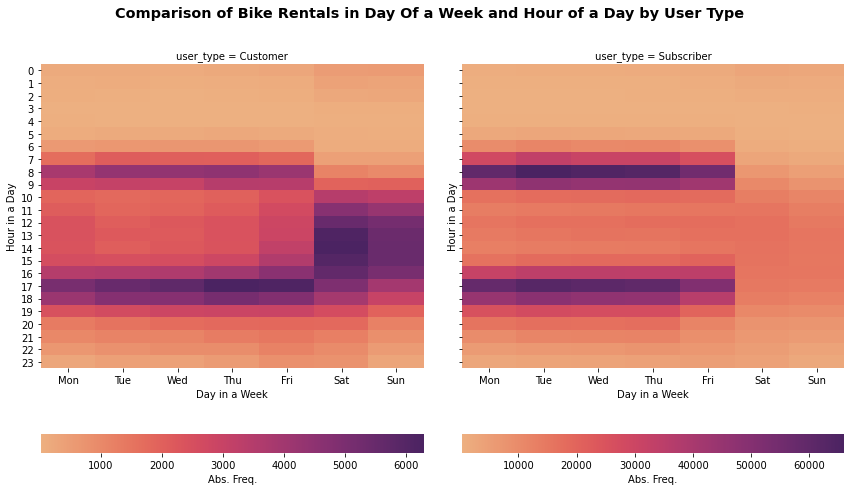

```python
def draw_heatmap(*args, **kwargs):
    """Construct the dataframe and create heatmap."""
    data = kwargs.pop('data')
    d = data.pivot(index=args[0], columns=args[1], values=args[2])
    sns.heatmap(d, **kwargs)

# Instantiate a `FacetGrid` object
fg = sns.FacetGrid(type_df, col='user_type', height=8, aspect=.9, gridspec_kws={"wspace":0.1})

# Map heatmap object with `FacetGrid` object
fg.map_dataframe(draw_heatmap, \
                 'start_time_hour', \
                 'start_time_dow', \
                 'bike_id', \
                 cmap='flare', \
                 cbar=True, \
                 cbar_kws={"orientation": "horizontal", 'label':'Abs. Freq.'})

# Reset x and y labels
fg.axes[0,0].set_xlabel('Day in a Week')
fg.axes[0,1].set_xlabel('Day in a Week')
fg.axes[0,0].set_ylabel('Hour in a Day')
fg.axes[0,1].set_ylabel('Hour in a Day')

fg.fig.suptitle("Comparison of Bike Rentals in Day Of a Week and Hour of a Day by User Type" ,
               fontsize = 'x-large' ,
               fontweight = 'bold' );
```

#### Insights

From the heatmaps, we can clearly see some interesting patterns for the bicycle rental behaviors for different user types although the counts of rentals for **Subscribers** are as **10 times** large as that for **Customers**:

### Multi-Variate Exploration 8. For different user type, what rental pattern does it have for different age ranges?

#### I. average duration time v.s. days of a week

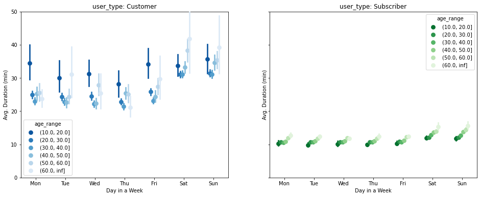

```python
fig, (ax1, ax2) = plt.subplots(1, 2, figsize = [16,6], sharey=True)


sns.pointplot(data = master_clean[master_clean.user_type=='Customer'], \
              x = 'start_time_dow', \
              y = 'duration_min', \
              hue = 'age_range', \
              palette = 'Blues_r', \
              linestyles = '', \
              dodge = 0.4, \
              ax=ax1)
ax1.set_title('user_type: Customer')
ax1.set_xlabel('Day in a Week')
ax1.set_ylabel('Avg. Duration (min)')
ax1.set_ylim((0, 50));


sns.pointplot(data = master_clean[master_clean.user_type=='Subscriber'], \
              x = 'start_time_dow', \
              y = 'duration_min', \
              hue = 'age_range', \
              palette = 'Greens_r', \
              linestyles = '', \
              dodge = 0.4, \
              ax=ax2);

ax2.set_title('user_type: Subscriber')
ax2.set_xlabel('Day in a Week')
ax2.set_ylabel('Avg. Duration (min)');
```

#### Insights

- **On weekdays**, the general level of average time spent by people from all age groups is obviously **lower** than that **at the weekends**, regardless of which **user type** they are.
- For **Customer** user type, the average duration time distribution for different age ranges throughout days of a week mostly look like letter **V shape** on the point plots although there are a few exceptions. Generally, younger and older users are prone to spend longer average time for a ride, while users **between 20 and 50** spend less.
- For **Customer** user type, the confidence interval at the two ends of age ranges is wider than the others as those samples are very small.
- For **Subscriber** user type, the average duration time distribution for different age ranges throughout days of a week are **more stable**: **Subscriber** users at younger age spend less average duration time for a ride, and as their ages grow, they tend to spend longer.
- For **Subscriber** user type, the distribution pattern from **Monday to Friday** is **quite similar** which implies that they almost spend the same duration time for a ride every weekday.

#### II. average trip distance v.s. days of a week

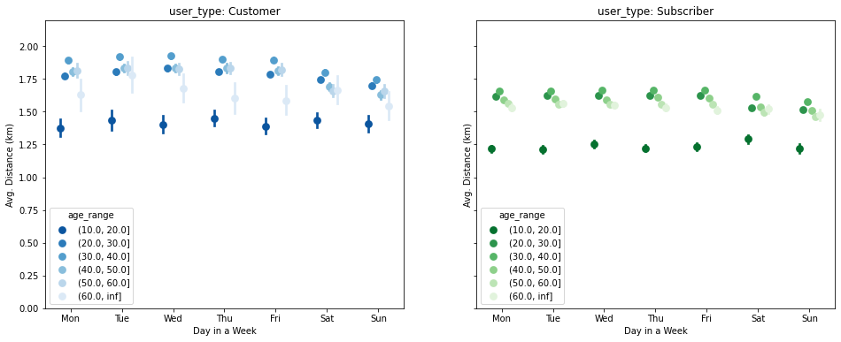

```python
fig, (ax1, ax2) = plt.subplots(1, 2, figsize = [16,6], sharey=True)


sns.pointplot(data = master_clean[master_clean.user_type=='Customer'], \
              x = 'start_time_dow', \
              y = 'trip_distance_km', \
              hue = 'age_range', \
              palette = 'Blues_r', \
              linestyles = '', \
              dodge = 0.4, \
              ax=ax1)
ax1.set_title('user_type: Customer')
ax1.set_xlabel('Day in a Week')
ax1.set_ylabel('Avg. Distance (km)')
ax1.set_ylim((0, 2.2));


sns.pointplot(data = master_clean[master_clean.user_type=='Subscriber'], \
              x = 'start_time_dow', \
              y = 'trip_distance_km', \
              hue = 'age_range', \
              palette = 'Greens_r', \
              linestyles = '', \
              dodge = 0.4, \
              ax=ax2);

ax2.set_title('user_type: Subscriber')
ax2.set_xlabel('Day in a Week')
ax2.set_ylabel('Avg. Distance (km)');
```

#### Insights

- Generally speaking, avg. distance values in **Subscriber** user type are relatively lower than that in **Customer** user type.
- Avg. disrance values of users in the age range of **(10, 20]** are distributed far away from the others, that is, values of users in the age range of **20 - 60** are more clustered together.
- Regardless of the **(10, 20]** group, avg. distances exhibit similar pattern: values are very close to each other, although they're generally larger **on weekdays** while smaller **at the weends**, no matter which **user type** they belong to.